# FTIR

2024-11-13

# FTIR PROCESSING - STATISTICAL ANALYSIS AND PLOTS

```r
library(parallel)

# Detect cores but reserve 2 for the system
n_cores <- max(1, detectCores() / 2) # Adjust the number of cores to use (e.g., use half of the available cores)
n_cores <-12
Sys.setenv(OMP_NUM_THREADS = n_cores)
Sys.setenv(MKL_NUM_THREADS = n_cores)
Sys.setenv(OPENBLAS_NUM_THREADS = n_cores)
Sys.setenv(VECLIB_MAXIMUM_THREADS = n_cores)

library(readr)
library(opusreader2) #Open OPUS files
library(prospectr) #IR spectrum processing
```

```r
library(ggplot2) #Plots
library(dplyr)
library(tidyr)
library(tidyverse)
library(tibble)
library(FactoMineR) #PCA analysis
library(factoextra) #Plot PCA results
library(pROC)
library(MASS) #LDA
library(caret) #Classification and Regression Training
library(ggpmisc) #Correlation plots
base_dir="/playground/sayol-altarriba_et_al_2026"
setwd(base_dir)
```

HEALTHY DONORS

Data loading

SCFAs levels from healthy donors and IR data files (OPUS files; .0):

```r
#SCFAs normalized levels - healthy donors:
scfa_hd <- read_csv("SCFA_normalised_HD.csv", col_names = TRUE, col_types = NULL)
#Create a variable named "sample_id_hd" to use it later for averageing spectra
sample_id_hd <- scfa_hd$sample_id

#Load FTIR data
spc_list_healthy <- read_opus(dsn = paste0(base_dir,"/OPUS_spectra_FTIR/Healthy_donors_IR/"), data_only = FALSE, parallel = FALSE, progress_bar = FALSE)


#We create an element for the wavenumbers (we could have used any sample as the x axis is the same for all the samples)
x_wave_list <- spc_list_healthy[["CLA33F(D_1)_D2.0"]][["ab"]][["wavenumbers"]]
```

Spectra processing

Each sample has 5 replicates (except 2 of them, that have 4 replicates –> CGR32F D.5 and MGM31F D.2), so we calculate the mean spectrum of each sample, having a single averaged spectrum per sample.

```r
#SPECTRA LIST --> Healthy donors
ir_names_healthy <- names(spc_list_healthy)

ir_healthy <- data.frame()
for (i in seq_along(sample_id_hd)) { #Iterate over each sample to get their 5 replicates
  pattern <- paste0("^", gsub("\\(", "\\\\(", gsub("\\)", "\\\\)", sample_id_hd[i])))
  replicates <- ir_names_healthy[grep(pattern, ir_names_healthy)]
  if (length(replicates) != 0){
      selected_matrices <- lapply(replicates, function(element) {
      return(t(spc_list_healthy[[element]]$ab$data))
  })
  df_with_all_replicates <- as.data.frame(do.call(cbind, selected_matrices))
  df_for_each_sample <- data.frame(row.names = sample_id_hd[i],t((average_spec = rowMeans(df_with_all_replicates))))
  ir_healthy <- rbind(ir_healthy, df_for_each_sample)
  }
}

#Remove the X before each wavenumber
colnames(ir_healthy) <- gsub("^X", "", colnames(ir_healthy))

#Data sorting (raw IR spectra)
raw_absorbance_hd <- ir_healthy %>%
  rownames_to_column(var = "sample_id") %>%  #Row names to column
  pivot_longer(cols = -sample_id,            #Select all columns except "sample_id"
               names_to = "wavenumber",     #Name for the wavenumber column
               values_to = "absorbance")    #Name for the absorbance values

#Remove the 'X' before the wavenumber value
raw_absorbance_hd$wavenumber <- gsub("X", "", raw_absorbance_hd$wavenumber)
raw_absorbance_hd$wavenumber <- as.numeric(raw_absorbance_hd$wavenumber)
```

1. Standard normal variate (SNV)

Facilitates interpretation as it passes the spectrum to whole numbers. Performed with the average spectra.

NOTE: The spectra shape does not change, but changes to whole numbers (absorbance), making it easier to understand.

2. Baseline correction

Appplied to SNV corrected data

3. Savitzky-Golay

We apply the second derivative to the curve. A Savitzky–Golay filter is a digital filter that can be applied to a set of digital data points for the purpose of smoothing the data, that is, to increase the precision of the data without distorting the digital tendency. The extremes of the dataframe are not included (the first and lasts wavenumbers are omitted).

Parameters:

m = 2 (an integer indicating the differentiation order, derivative order)

p = 3 (an integer indicating the polynomial order)

w = 9 (window size, must be odd)

```r
#SPECTRA PROCESSING
#A) STANDARD NORMAL VARIATE --> With average data (the spectra shape does not change, but changes to enter numbers, making it easier to understand)
ir_healthy_snv <- data.frame()
for (i in 1:nrow(ir_healthy)){
  print(i)
  ir_healthy_snv <- rbind(ir_healthy_snv,data.frame(standardNormalVariate(ir_healthy[i,])))
}
```

[output not shown]

[output cut: 100 more lines]

```r
rownames(ir_healthy_snv) <- rownames(ir_healthy)
ir_healthy_snv
```

[output not shown]

[output cut: 18187 more lines]

[output not shown]

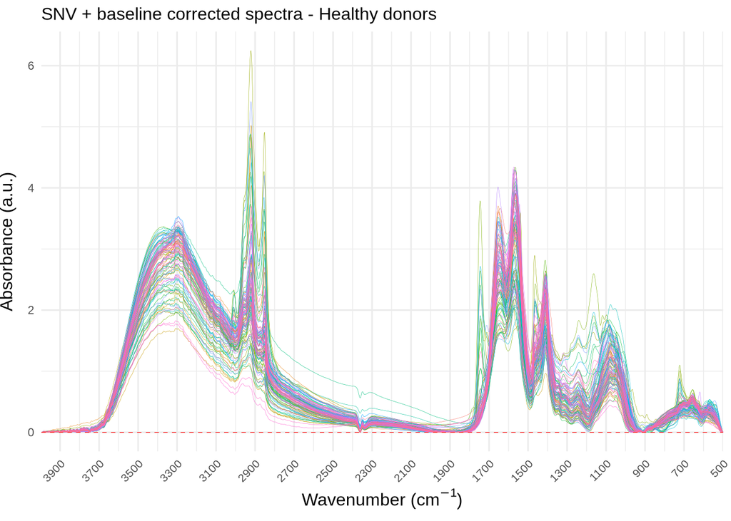

```r
#Data sorting (STANDARD NORMAL VARIATE DATA)
snv_data_hd <- ir_healthy_snv %>%
  rownames_to_column(var = "sample_id") %>%  #Row names to column
  pivot_longer(cols = -sample_id,            #Select all columns except "sample_id"
               names_to = "wavenumber",     #Name for the wavenumber column
               values_to = "absorbance")    #Name for the absorbance values

#Remove the 'X' before the wavenumber value
snv_data_hd$wavenumber <- gsub("X", "", snv_data_hd$wavenumber)
snv_data_hd$wavenumber <- as.numeric(snv_data_hd$wavenumber)

#B) BASELINE CORRECTION --> Applied to SNV corrected data
ir_healthy_bsln <- data.frame()
for (i in 1:nrow(ir_healthy_snv)){
  numeric_vector <- ir_healthy_snv[i,]
  row_df <- data.frame(matrix(baseline(numeric_vector), nrow = 1, ncol = length(numeric_vector)))
  ir_healthy_bsln <- rbind(ir_healthy_bsln,row_df)
}

colnames(ir_healthy_bsln) <- colnames(ir_healthy)
rownames(ir_healthy_bsln) <- rownames(ir_healthy)

#Data sorting (BASELINE CORRECTED DATA)
bsln_data_hd <- ir_healthy_bsln %>%
  rownames_to_column(var = "sample_id") %>%  #Row names to column
  pivot_longer(cols = -sample_id,            #Select all columns except "sample_id"
               names_to = "wavenumber",     #Name for the wavenumber column
               values_to = "absorbance")    #Name for the absorbance values

#Remove the 'X' before the wavenumber value
bsln_data_hd$wavenumber <- gsub("X", "", bsln_data_hd$wavenumber)
bsln_data_hd$wavenumber <- as.numeric(bsln_data_hd$wavenumber)

#SNV + baseline correction plot (per sample) --> Check data visualization
blsn_hd_plot <- ggplot(bsln_data_hd, aes(x = wavenumber, y = absorbance, color = sample_id)) +
  geom_line(linewidth = 0.1) +
  geom_hline(yintercept=0.0, linetype="dashed",color = "red", linewidth = 0.2) +
  labs(x = expression("Wavenumber (cm"^-1*")"), y = "Absorbance (a.u.)", title = "SNV + baseline corrected spectra - Healthy donors") +
  scale_x_continuous(breaks = seq(min(bsln_data_hd$wavenumber), max(bsln_data_hd$wavenumber), by = 200), labels = seq(min(bsln_data_hd$wavenumber), max(bsln_data_hd$wavenumber), by = 200), expand = c(0, 0), trans = "reverse") +
  theme_minimal() +
  theme(text = element_text(size = 10),
        axis.title.y = element_text(vjust = +3, size = 12),
        axis.title.x = element_text(vjust = +1, size = 12),
        axis.ticks.x=element_blank(),
        axis.text.x = element_text(angle = 45, hjust = 1),
        legend.position = "none",
        legend.text=element_text(size = 10))

blsn_hd_plot
```

```r
#C) SAVITZKY-GOLAY --> 2nd derivate
ir_healthy_skg <- data.frame()
for (i in 1:nrow(ir_healthy_bsln)){
  numeric_vector <- ir_healthy_bsln[i,]
  row_df <- data.frame(savitzkyGolay(X = numeric_vector, m = 2, p = 3, w = 9))
  ir_healthy_skg <- rbind(ir_healthy_skg,row_df)
}

#Remove the X before each wavelenght
colnames(ir_healthy_skg) <- gsub("^X", "", colnames(ir_healthy_skg))

#Data sorting (SAVITZKY-GOLAY CORRECTED DATA)
skg_data_hd <- ir_healthy_skg %>%
  rownames_to_column(var = "sample_id") %>%  #Row names to column
  pivot_longer(cols = -sample_id,            #Select all columns except "sample_id"
               names_to = "wavenumber",     #Name for the wavenumber column
               values_to = "absorbance")    #Name for the absorbance values

#Remove the 'X' before the wavenumber value
skg_data_hd$wavenumber <- gsub("X", "", skg_data_hd$wavenumber)
skg_data_hd$wavenumber <- as.numeric(skg_data_hd$wavenumber)
```

CDI PATIENTS

Data loading

SCFAs levels from patients with Clostidioides difficile infection (CDI) and IR data files (OPUS files; .0):

```r
#Raw data - C.difficile patients:
scfa_cdiff <- read_csv("SCFA_normalised_CDIFF.csv", col_names = TRUE, col_types = NULL)
#Create a variable named "sample_id_hd" to use it later for averageing spectra
sample_id_cdiff <- scfa_cdiff$sample_id

#Load FTIR data
spc_list_cdiff <- read_opus(dsn = paste0(base_dir,"/OPUS_spectra_FTIR/Cdifficile_IR/"), data_only = FALSE, parallel = FALSE, progress_bar = FALSE)
```

Spectra processing

Each sample has 5 replicates, so we calculate the mean spectrum of each sample, having a single averaged spectrum per sample.

```r
#SPECTRA LIST --> C. difficile pateints
ir_names_cdiff <- names(spc_list_cdiff)

ir_cdiff <- data.frame()
for (i in seq_along(sample_id_cdiff)) { # iterate over each sample to get their 5 replicates
  replicates <- ir_names_cdiff[grep(sample_id_cdiff[i], ir_names_cdiff)]
  if (length(replicates) != 0){
      selected_matrices <- lapply(replicates, function(element) {
      return(t(spc_list_cdiff[[element]]$ab$data))
  })
  df_with_all_replicates <- as.data.frame(do.call(cbind, selected_matrices))
  df_for_each_sample <- data.frame(row.names = sample_id_cdiff[i],t((average_spec = rowMeans(df_with_all_replicates))))
  ir_cdiff <- rbind(ir_cdiff, df_for_each_sample)
  }
}

#Remove the X before each wavelenght
colnames(ir_cdiff) <- gsub("^X", "", colnames(ir_cdiff))

#Data sorting (raw IR spectra)
raw_absorbance_cdiff <- ir_cdiff %>%
  rownames_to_column(var = "sample_id") %>%  #Row names to column
  pivot_longer(cols = -sample_id,            #Select all columns except "sample_id"
               names_to = "wavenumber",     #Name for the wavenumber column
               values_to = "absorbance")    #Name for the absorbance values

#Remove the 'X' before the wavenumber value
raw_absorbance_cdiff$wavenumber <- gsub("X", "", raw_absorbance_cdiff$wavenumber)
raw_absorbance_cdiff$wavenumber <- as.numeric(raw_absorbance_cdiff$wavenumber)
```

Processing:

```r
#SPECTRA PROCESSING
#A) STANDARD NORMAL VARIATE --> With average data (the spectra form does not change, but changes to enter numbers, making it easier to understand)
ir_cdiff_snv <- data.frame()
for (i in 1:nrow(ir_cdiff)){
  print(i)
  ir_cdiff_snv <- rbind(ir_cdiff_snv,data.frame(standardNormalVariate(ir_cdiff[i,])))
}
```

[output not shown]

[output cut: 25 more lines]

```r
rownames(ir_cdiff_snv) <- rownames(ir_cdiff)
ir_cdiff_snv
```

[output not shown]

[output cut: 16708 more lines]

[output not shown]

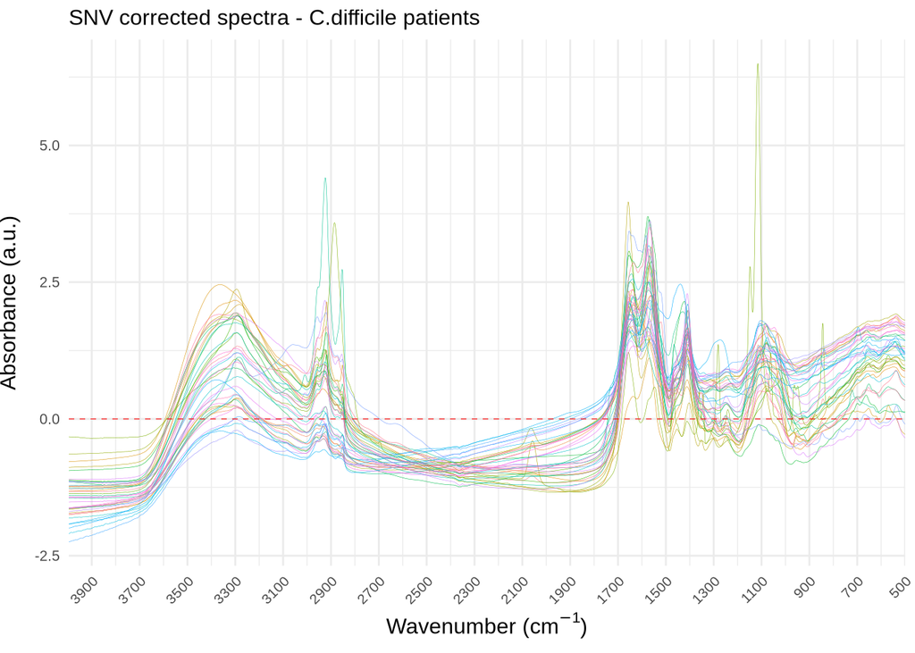

```r
#Data sorting (STANDARD NORMAL VARIATE DATA)
snv_data_cdiff <- ir_cdiff_snv %>%
  rownames_to_column(var = "sample_id") %>%  #Row names to column
  pivot_longer(cols = -sample_id,            #Select all columns except "sample_id"
               names_to = "wavenumber",     #Name for the wavenumber column
               values_to = "absorbance")    #Name for the absorbance values

#Remove the 'X' before the wavenumber value
snv_data_cdiff$wavenumber <- gsub("X", "", snv_data_cdiff$wavenumber)
snv_data_cdiff$wavenumber <- as.numeric(snv_data_cdiff$wavenumber)

#SNV plot (per sample) --> Check data visualization
snv_cdiff_plot <- ggplot(snv_data_cdiff, aes(x = wavenumber, y = absorbance, color = sample_id)) +
  geom_line(linewidth = 0.1) +
  geom_hline(yintercept=0.0, linetype="dashed",color = "red", linewidth = 0.2) +
  labs(x = expression("Wavenumber (cm"^-1*")"), y = "Absorbance (a.u.)", title = "SNV corrected spectra - C.difficile patients") +
  scale_x_continuous(breaks = seq(min(snv_data_cdiff$wavenumber), max(snv_data_cdiff$wavenumber), by = 200), labels = seq(min(snv_data_cdiff$wavenumber), max(snv_data_cdiff$wavenumber), by = 200), expand = c(0, 0), trans = "reverse") +
  theme_minimal() +
  theme(text = element_text(size = 10),
        axis.title.y = element_text(vjust = +3, size = 12),
        axis.title.x = element_text(vjust = +1, size = 12),
        axis.ticks.x=element_blank(),
        axis.text.x = element_text(angle = 45, hjust = 1),
        legend.position = "none",
        legend.text=element_text(size = 10))

snv_cdiff_plot
```

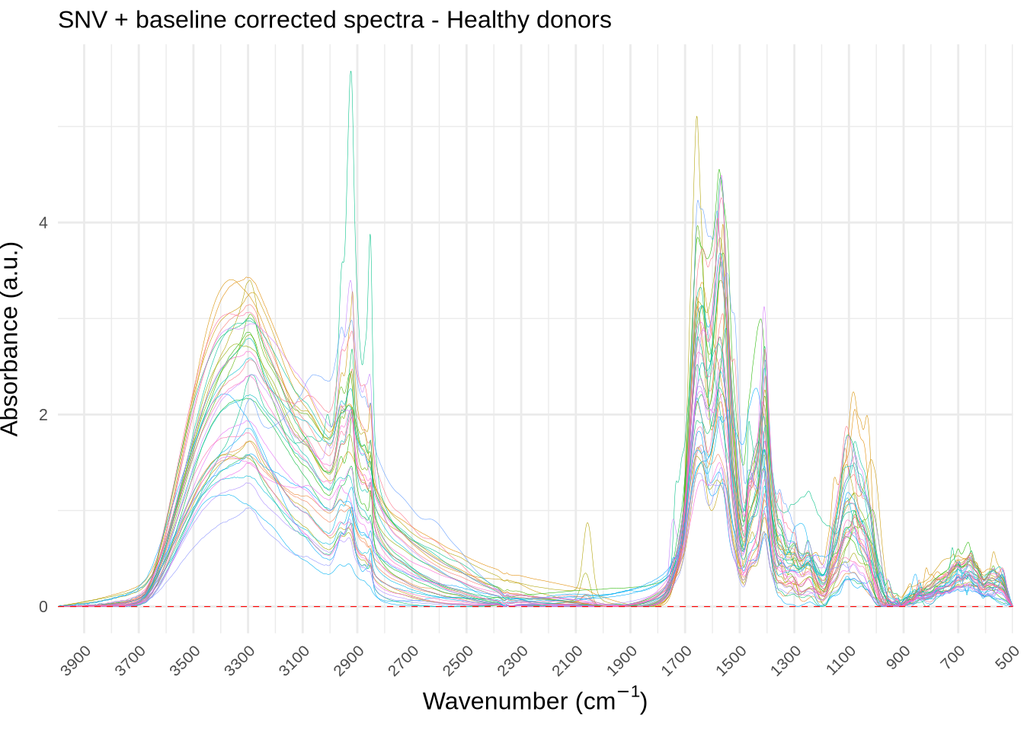

```r
#There is one sample that has a very intensive peak at 1100, so we will delete that sample for further analysis. We consider it an outlier (removed after baseline correction)

#B) BASELINE CORRECTION --> Applied to SNV corrected data
ir_cdiff_bsln <- data.frame()
for (i in 1:nrow(ir_cdiff_snv)){
  numeric_vector <- ir_cdiff_snv[i,]
  row_df <- data.frame(matrix(baseline(numeric_vector), nrow = 1, ncol = length(numeric_vector)))
  ir_cdiff_bsln <- rbind(ir_cdiff_bsln,row_df)
}

#Now remove row 19, which we consider an outlier
ir_cdiff_bsln <- ir_cdiff_bsln[-19, ] # Outlier removal
colnames(ir_cdiff_bsln) <- colnames(ir_cdiff) #Use original column names
rownames(ir_cdiff_bsln) <- rownames(ir_cdiff[-19, ]) #Use original row names (excluding row 19)

#Remove it from SCFA data
scfa_cdiff <- scfa_cdiff[-19, ] # Remove outlier

#Data sorting (BASELINE CORRECTED DATA)
bsln_data_cdiff <- ir_cdiff_bsln %>%
  rownames_to_column(var = "sample_id") %>%  #Row names to column
  pivot_longer(cols = -sample_id,            #Select all columns except "sample_id"
               names_to = "wavenumber",     #Name for the wavenumber column
               values_to = "absorbance")    #Name for the absorbance values

#Remove the 'X' before the wavenumber value
bsln_data_cdiff$wavenumber <- gsub("X", "", bsln_data_cdiff$wavenumber)
bsln_data_cdiff$wavenumber <- as.numeric(bsln_data_cdiff$wavenumber)

#SNV + baseline correction plot (per sample) --> Check data visualization
blsn_cdiff_plot <- ggplot(bsln_data_cdiff, aes(x = wavenumber, y = absorbance, color = sample_id)) +
  geom_line(linewidth = 0.1) +
  geom_hline(yintercept=0.0, linetype="dashed",color = "red", linewidth = 0.2) +
  labs(x = expression("Wavenumber (cm"^-1*")"), y = "Absorbance (a.u.)", title = "SNV + baseline corrected spectra - Healthy donors") +
  scale_x_continuous(breaks = seq(min(bsln_data_cdiff$wavenumber), max(bsln_data_cdiff$wavenumber), by = 200), labels = seq(min(bsln_data_cdiff$wavenumber), max(bsln_data_cdiff$wavenumber), by = 200), expand = c(0, 0), trans = "reverse") +
  theme_minimal() +
  theme(text = element_text(size = 10),
        axis.title.y = element_text(vjust = +3, size = 12),
        axis.title.x = element_text(vjust = +1, size = 12),
        axis.ticks.x=element_blank(),
        axis.text.x = element_text(angle = 45, hjust = 1),
        legend.position = "none",
        legend.text=element_text(size = 10))

blsn_cdiff_plot
```

```r
#C) SAVITZKY-GOLAY --> 2nd derivate
ir_cdiff_sgk <- data.frame()
for (i in 1:nrow(ir_cdiff_bsln)){
  numeric_vector <- ir_cdiff_bsln[i,]
  row_df <- data.frame(savitzkyGolay(X = numeric_vector, m = 2, p = 3, w = 9))
  ir_cdiff_sgk <- rbind(ir_cdiff_sgk,row_df)
}

#Remove the X before each wavelenght
colnames(ir_cdiff_sgk) <- gsub("^X", "", colnames(ir_cdiff_sgk))

#Data sorting (SAVITZKY-GOLAY CORRECTED DATA)
skg_data_cdiff <- ir_cdiff_sgk %>%
  rownames_to_column(var = "sample_id") %>%  #Row names to column
  pivot_longer(cols = -sample_id,            #Select all columns except "sample_id"
               names_to = "wavenumber",     #Name for the wavenumber column
               values_to = "absorbance")    #Name for the absorbance values

#Remove the 'X' before the wavenumber value
skg_data_cdiff$wavenumber <- gsub("X", "", skg_data_cdiff$wavenumber)
skg_data_cdiff$wavenumber <- as.numeric(skg_data_cdiff$wavenumber)
```

ABSORBANCE PLOTS

```r
#HEALTHY DONORS
#Add tag to indicate the patient type
bsln_data_hd <- bsln_data_hd %>% mutate(patient_type = "healthy_donor")

#C. difficile PATIENTS
#Add tag to indicate the patient type
bsln_data_cdiff <- bsln_data_cdiff %>% mutate(patient_type = "cdiff_patient")

#MERGE THE TWO DATAFRAMES
corrected_ir_data <- rbind(bsln_data_hd, bsln_data_cdiff)

#MERGE THE TWO DATAFRAMES
corrected_ir_avg <- corrected_ir_data %>%
  group_by(patient_type, wavenumber) %>%
  summarize(absorbance_avg = mean(absorbance, na.rm = TRUE), .groups = "drop")
```

Average healthy vs. CDI (Fig. 1B)

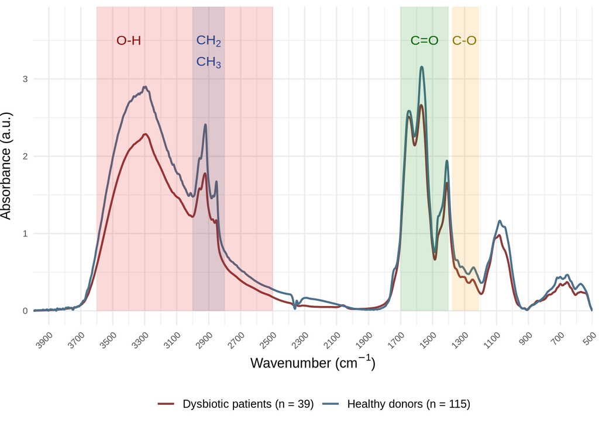

```r
#TOTAL PLOT (SNV + baseline correction plot (average))
plot_bonds <- ggplot(corrected_ir_avg, aes(x = wavenumber, y = absorbance_avg, colour = patient_type)) +
  geom_line(linewidth = 0.8) +
  scale_colour_manual(values = c("healthy_donor" = "skyblue4", "cdiff_patient" = "indianred4"), name = NULL, labels = c("Dysbiotic patients (n = 39)", "Healthy donors (n = 115)")) +
  labs(x = expression("Wavenumber (cm"^-1*")"), y = "Absorbance (a.u.)") +
  annotate("rect", xmin=3600, xmax=2500, ymin=0, ymax=Inf, alpha=0.15, fill="red2") + #O-H region +
  annotate("text", x = 3400, y = 3.5, label = paste0("O-H"), color = "red4", size = 4, hjust = 0.5) + #O-H letters
  annotate("rect", xmin=3000, xmax=2800, ymin=0, ymax=Inf, alpha=0.15, fill="steelblue4") + #CH region
  annotate("text", x = 2900, y = 3.35, label = "atop(CH[2], CH[3])", parse = TRUE, color = "royalblue4", size = 4, hjust = 0.5) + #CH2/CH3 letters
  annotate("rect", xmin=1700, xmax=1400, ymin=0, ymax=Inf, alpha=0.15, fill="green4") + #C=O region
  annotate("text", x = 1550, y = 3.5, label = paste0("C=O"), color = "darkgreen", size = 4, hjust = 0.5) + #C=O letters
  annotate("rect", xmin=1380, xmax=1210, ymin=0, ymax=Inf, alpha=0.15, fill="orange2") + #C-O region
    annotate("text", x = 1300, y = 3.5, label = paste0("C-O"), color = "gold4", size = 4, hjust = 0.5) + #C=O letters
  scale_x_continuous(breaks = seq(min(corrected_ir_data$wavenumber), max(corrected_ir_data$wavenumber), by = 200), labels = seq(min(corrected_ir_data$wavenumber), max(corrected_ir_data$wavenumber), by = 200), expand = c(0, 0), trans = "reverse") +
  scale_y_continuous(limits = c(0, 3.75), breaks = c(0, 1, 2, 3)) +
    theme_minimal() +
  theme(text = element_text(size = 9.5),
        axis.title.y = element_text(vjust = +3, size = 11.5),
        axis.title.x = element_text(vjust = +1, size = 11.5),
        axis.ticks.x=element_blank(),
        axis.text.x = element_text(angle = 45, hjust = 1),
        legend.position = "bottom",
        legend.text=element_text(size = 9.5))

plot_bonds
```

```r
#ggsave("Figures_paper/Fig1B.Spectra_regions.jpeg", width = 6, height = 4, units = "in", dpi = 600)
```

Savitzky-Golay (Supp. Fig. S1)

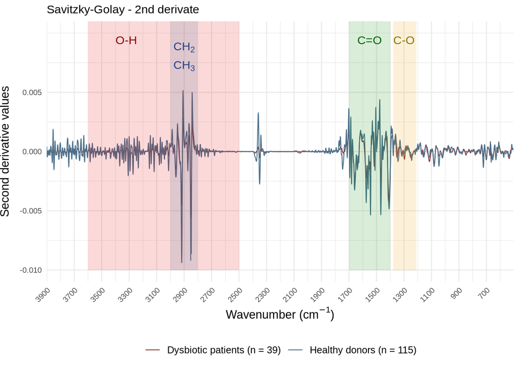

```r
#HEALTHY DONORS
#Add tag to indicate the patient type
skg_data_hd <- skg_data_hd %>% mutate(patient_type = "healthy_donor")

#C. difficile PATIENTS
#Add tag to indicate the patient type
skg_data_cdiff <- skg_data_cdiff %>% mutate(patient_type = "cdiff_patient")

#MERGE THE TWO DATAFRAMES
skg_total_avg <- rbind(skg_data_hd, skg_data_cdiff)

#MERGE THE TWO DATAFRAMES
skg_total_avg <- skg_total_avg %>%
  group_by(patient_type, wavenumber) %>%
  summarize(absorbance_avg = mean(absorbance, na.rm = TRUE), .groups = "drop")

filtered_skg_average <- skg_total_avg %>% dplyr::filter(wavenumber >= 500 & wavenumber <= 3900)

#TOTAL PLOT (SNV + baseline correction plot (per sample))
skg_avg_plot <- ggplot(filtered_skg_average, aes(x = wavenumber, y = absorbance_avg, color = patient_type)) +
  geom_line(linewidth = 0.4) +
  scale_colour_manual(values = c("healthy_donor" = "skyblue4", "cdiff_patient" = "indianred4"), name = NULL, labels = c("Dysbiotic patients (n = 39)", "Healthy donors (n = 115)")) +
  labs(x = expression("Wavenumber (cm"^-1*")"), y = "Second derivative values", title = "Savitzky-Golay - 2nd derivate") +
  annotate("rect", xmin=3600, xmax=2500, ymin=-0.010, ymax=Inf, alpha=0.15, fill="red2") + #O-H region
  annotate("text", x = 3400, y = 0.0094, label = paste0("O-H"), color = "red4", size = 4, hjust = 0) + #O-H letters
  annotate("rect", xmin=3000, xmax=2800, ymin=-0.010, ymax=Inf, alpha=0.15, fill="steelblue4") + #CH region
annotate("text", x = 2900, y = 0.008, label = "atop(CH[2], CH[3])", parse = TRUE, color = "royalblue4", size = 4, hjust = 0.5) + #CH2/CH3 letters
  annotate("rect", xmin=1700, xmax=1400, ymin=-0.010, ymax=Inf, alpha=0.15, fill="green4") + #C=O region
  annotate("text", x = 1550, y = 0.0094, label = paste0("C=O"), color = "darkgreen", size = 4, hjust = 0.5) + #C=O letters
  annotate("rect", xmin=1380, xmax=1210, ymin=-0.010, ymax=Inf, alpha=0.15, fill="orange2") + #C-O region
    annotate("text", x = 1300, y = 0.0094, label = paste0("C-O"), color = "gold4", size = 4, hjust = 0.5) + #C=O letters
  scale_x_continuous(breaks = seq(500, 3900, by = 200), expand = c(0, 0), trans = "reverse") +
  scale_y_continuous(limits = c(-0.010, 0.01), breaks = c(-0.010, -0.005, 0.000, 0.005)) +
  theme_minimal() +
  theme(text = element_text(size = 9.5),
      axis.title.y = element_text(vjust = +3, size = 11.5),
      axis.title.x = element_text(vjust = +1, size = 11.5),
      axis.ticks.x=element_blank(),
      axis.text.x = element_text(angle = 45, hjust = 1),
      legend.position = "bottom",
      legend.text=element_text(size = 9.5))

skg_avg_plot
```

```r
#ggsave("Figures_paper/SupFigS1.Savitsky-Golay.jpeg", width = 6, height = 4, units = "in", dpi = 600)
```

PCA - PRINCIPAL COMPONENT ANALYSIS

For the PCA analysis we need (FactoMineR package):

X = a data frame with n rows (individuals) and p columns (numeric variables)

ncp = number of dimensions kept in the results (by default 5)

quali.sup = column of qualitative data (for example patient type, in this case is column 1)

(http://www.sthda.com/english/wiki/wiki.php?id_contents=7851#supplementary-qualitative-variables)

PCA - Selected regions (Fig. 1A)

```r
#Merge data from Savitzky-Golay (2nd derivate)
#For the PCA analysis we need a single dataframe with n rows (individuals) and p columns (numeric variables)
ir_skg_total <- rbind(ir_healthy_skg, ir_cdiff_sgk) %>%
  mutate(patient_type = rep(c("Healthy donors", "Dysbiotic patients"), times = c(115, 39))) %>%
  dplyr::select(patient_type, everything()) # Places `patient_type` at the begining

#write.csv(ir_skg_total, "ir_skg_data.csv")

#Selected columns according to groups and bonds in SCFA (O-H, C-H, C=O, C-O)
which(colnames(ir_skg_total) == "1210") #To check the column of the variable
```

```
## [1] 2784
```

```r
ir_filtered <- ir_skg_total %>% dplyr::select(1, 394:1494, 2294:2594, 2614:2784)

#Selected reg --> (patient_type, 3600(394):2500(1494) , 1700(2294):1400(2594), 1380(2614):1210(2784))

#PCA
#The variable 'patient_type' (column = 1) is removed before the PCA analysis
pca_skg_regions <- PCA(ir_filtered, ncp = 5, scale.unit = TRUE, quali.sup = 1)
```

[figure not shown]

```r
#OUTPUTS PCA
summary(pca_skg_regions)  #Summary of PCA
```

```
##
## Call:
## PCA(X = ir_filtered, scale.unit = TRUE, ncp = 5, quali.sup = 1)
##
##
## Eigenvalues
##                        Dim.1   Dim.2   Dim.3   Dim.4   Dim.5   Dim.6   Dim.7
## Variance             453.254 208.704 119.176  71.023  63.648  53.599  38.474
## % of var.             28.815  13.268   7.576   4.515   4.046   3.407   2.446
## Cumulative % of var.  28.815  42.082  49.659  54.174  58.220  61.628  64.074
##                        Dim.8   Dim.9  Dim.10  Dim.11  Dim.12  Dim.13  Dim.14
## Variance              35.252  27.300  24.164  20.988  20.582  19.193  17.786
## % of var.              2.241   1.736   1.536   1.334   1.308   1.220   1.131
## Cumulative % of var.  66.315  68.050  69.586  70.921  72.229  73.449  74.580
##                       Dim.15  Dim.16  Dim.17  Dim.18  Dim.19  Dim.20  Dim.21
## Variance              16.556  15.588  14.376  13.731  13.225  12.686  11.767
## % of var.              1.053   0.991   0.914   0.873   0.841   0.806   0.748
## Cumulative % of var.  75.632  76.623  77.537  78.410  79.251  80.057  80.805
##                       Dim.22  Dim.23  Dim.24  Dim.25  Dim.26  Dim.27  Dim.28
## Variance              11.180  10.907  10.018   9.542   8.990   8.871   8.584
## % of var.              0.711   0.693   0.637   0.607   0.572   0.564   0.546
## Cumulative % of var.  81.516  82.210  82.846  83.453  84.024  84.588  85.134
##                       Dim.29  Dim.30  Dim.31  Dim.32  Dim.33  Dim.34  Dim.35
## Variance               8.209   7.704   7.456   7.246   7.158   6.939   6.510
## % of var.              0.522   0.490   0.474   0.461   0.455   0.441   0.414
## Cumulative % of var.  85.656  86.146  86.620  87.080  87.536  87.977  88.391
##                       Dim.36  Dim.37  Dim.38  Dim.39  Dim.40  Dim.41  Dim.42
## Variance               6.340   6.065   5.799   5.668   5.601   5.247   5.102
## % of var.              0.403   0.386   0.369   0.360   0.356   0.334   0.324
## Cumulative % of var.  88.794  89.179  89.548  89.908  90.264  90.598  90.922
##                       Dim.43  Dim.44  Dim.45  Dim.46  Dim.47  Dim.48  Dim.49
## Variance               4.783   4.677   4.597   4.504   4.230   4.102   4.025
## % of var.              0.304   0.297   0.292   0.286   0.269   0.261   0.256
## Cumulative % of var.  91.226  91.524  91.816  92.102  92.371  92.632  92.888
##                       Dim.50  Dim.51  Dim.52  Dim.53  Dim.54  Dim.55  Dim.56
## Variance               3.858   3.787   3.657   3.581   3.477   3.390   3.346
## % of var.              0.245   0.241   0.233   0.228   0.221   0.215   0.213
## Cumulative % of var.  93.133  93.374  93.606  93.834  94.055  94.270  94.483
##                       Dim.57  Dim.58  Dim.59  Dim.60  Dim.61  Dim.62  Dim.63
## Variance               3.259   2.987   2.929   2.669   2.641   2.566   2.476
```

[output cut: 95 more lines]

```
## 3597                0.012  0.015 |
## 3596                0.047  0.056 |
## 3595                0.071  0.084 |
## 3594                0.088  0.105 |
## 3593                0.093  0.111 |
## 3592                0.058  0.069 |
## 3591                0.032  0.039 |
##
## Supplementary categories
##                         Dist     Dim.1    cos2  v.test     Dim.2    cos2
## Dysbiotic patients |  30.007 | -27.862   0.862  -9.427 |   9.333   0.097
## Healthy donors     |  10.176 |   9.449   0.862   9.427 |  -3.165   0.097
##                     v.test     Dim.3    cos2  v.test
## Dysbiotic patients   4.653 |  -4.065   0.018  -2.682 |
## Healthy donors      -4.653 |   1.379   0.018   2.682 |
```

```r
#Eigenvalues --> a matrix containing all the eigenvalues, the percentage of variance and the cumulative percentage of variance
pca_skg_regions$eig
```

```
##            eigenvalue percentage of variance cumulative percentage of variance
## comp 1   4.532537e+02           2.881460e+01                          28.81460
## comp 2   2.087037e+02           1.326788e+01                          42.08248
## comp 3   1.191758e+02           7.576339e+00                          49.65882
## comp 4   7.102294e+01           4.515127e+00                          54.17395
## comp 5   6.364752e+01           4.046250e+00                          58.22020
## comp 6   5.359896e+01           3.407435e+00                          61.62763
## comp 7   3.847430e+01           2.445919e+00                          64.07355
## comp 8   3.525152e+01           2.241037e+00                          66.31459
## comp 9   2.730042e+01           1.735564e+00                          68.05015
## comp 10  2.416396e+01           1.536170e+00                          69.58632
## comp 11  2.098800e+01           1.334265e+00                          70.92059
## comp 12  2.058163e+01           1.308432e+00                          72.22902
## comp 13  1.919263e+01           1.220129e+00                          73.44915
## comp 14  1.778614e+01           1.130714e+00                          74.57986
## comp 15  1.655585e+01           1.052502e+00                          75.63236
## comp 16  1.558783e+01           9.909617e-01                          76.62333
## comp 17  1.437558e+01           9.138956e-01                          77.53722
## comp 18  1.373073e+01           8.729008e-01                          78.41012
## comp 19  1.322495e+01           8.407468e-01                          79.25087
## comp 20  1.268611e+01           8.064913e-01                          80.05736
## comp 21  1.176722e+01           7.480751e-01                          80.80544
## comp 22  1.117957e+01           7.107162e-01                          81.51615
## comp 23  1.090676e+01           6.933733e-01                          82.20953
## comp 24  1.001777e+01           6.368575e-01                          82.84638
## comp 25  9.541855e+00           6.066023e-01                          83.45299
## comp 26  8.989917e+00           5.715141e-01                          84.02450
## comp 27  8.870928e+00           5.639497e-01                          84.58845
## comp 28  8.583565e+00           5.456812e-01                          85.13413
## comp 29  8.209152e+00           5.218787e-01                          85.65601
## comp 30  7.703783e+00           4.897510e-01                          86.14576
## comp 31  7.456072e+00           4.740033e-01                          86.61976
## comp 32  7.246386e+00           4.606730e-01                          87.08044
## comp 33  7.158486e+00           4.550849e-01                          87.53552
## comp 34  6.939411e+00           4.411577e-01                          87.97668
## comp 35  6.509787e+00           4.138453e-01                          88.39052
## comp 36  6.339771e+00           4.030370e-01                          88.79356
## comp 37  6.065455e+00           3.855979e-01                          89.17916
## comp 38  5.798886e+00           3.686513e-01                          89.54781
## comp 39  5.667920e+00           3.603255e-01                          89.90814
```

[output cut: 99 more lines]

```
## comp 139 1.441362e-01           9.163141e-03                          99.92103
## comp 140 1.403678e-01           8.923576e-03                          99.92995
## comp 141 1.370297e-01           8.711359e-03                          99.93867
## comp 142 1.251121e-01           7.953725e-03                          99.94662
## comp 143 1.211299e-01           7.700567e-03                          99.95432
## comp 144 1.168161e-01           7.426323e-03                          99.96175
## comp 145 1.045733e-01           6.648017e-03                          99.96839
## comp 146 9.952015e-02           6.326774e-03                          99.97472
## comp 147 9.367043e-02           5.954890e-03                          99.98068
## comp 148 8.341799e-02           5.303114e-03                          99.98598
## comp 149 8.062570e-02           5.125600e-03                          99.99110
## comp 150 6.530870e-02           4.151856e-03                          99.99526
## comp 151 5.752795e-02           3.657212e-03                          99.99891
## comp 152 1.275995e-02           8.111857e-04                          99.99972
## comp 153 4.331812e-03           2.753854e-04                         100.00000
```

```r
#Coordinates (loadings) --> a list of matrices containing all the results for the active variables (coordinates, correlation between variables and axes, square cosine, contributions)
pca_skg_regions$var$coord
```

```
##             Dim.1         Dim.2         Dim.3         Dim.4         Dim.5
## 3600 -0.483854029  0.2132187555  4.081423e-01 -0.3281422169 -0.0010832395
## 3599 -0.177433303  0.1048127079  3.860959e-01 -0.3528123482 -0.0077648610
## 3598  0.297748012 -0.1044169791  1.520580e-01 -0.1729437663  0.0681347164
## 3597  0.444377220 -0.1896569924 -1.218936e-01  0.0918066603  0.1407992083
## 3596  0.356475640 -0.1565674669 -2.370315e-01  0.2249101736  0.1731171313
## 3595  0.305710605 -0.1106922610 -2.900403e-01  0.2751386422  0.1641773572
## 3594  0.375945633 -0.0808533197 -3.244439e-01  0.2680832615  0.1093192668
## 3593  0.607892678 -0.0846111841 -3.335887e-01  0.1816209121 -0.0127975453
## 3592  0.806927212 -0.1149992561 -2.620689e-01  0.0276114074 -0.1429497390
## 3591  0.840351566 -0.1326771353 -1.966801e-01 -0.0618234751 -0.1974682679
## 3590  0.830014522 -0.1454542190 -1.669974e-01 -0.0979327022 -0.2146547167
## 3589  0.790236217 -0.1531462607 -1.535761e-01 -0.1171264543 -0.2236035266
## 3588  0.615458381 -0.1459202313 -1.360648e-01 -0.1331084899 -0.2259441911
## 3587 -0.396452226  0.0071137759  5.462346e-02 -0.0955310800 -0.0501296527
```

[output cut: 1559 more lines]

```r
#Individual scores --> a list of matrices containing all the results for the active individuals (coordinates, square cosine, contributions)
comp_ind <- pca_skg_regions$ind$coord

#Check how many eigenvalues follow the Kaiser's criterium
sum(pca_skg_regions$eig[, 1] > 1)
```

```
## [1] 90
```

```
## Ignoring unknown labels:
## • linetype : "Patient Type"
```

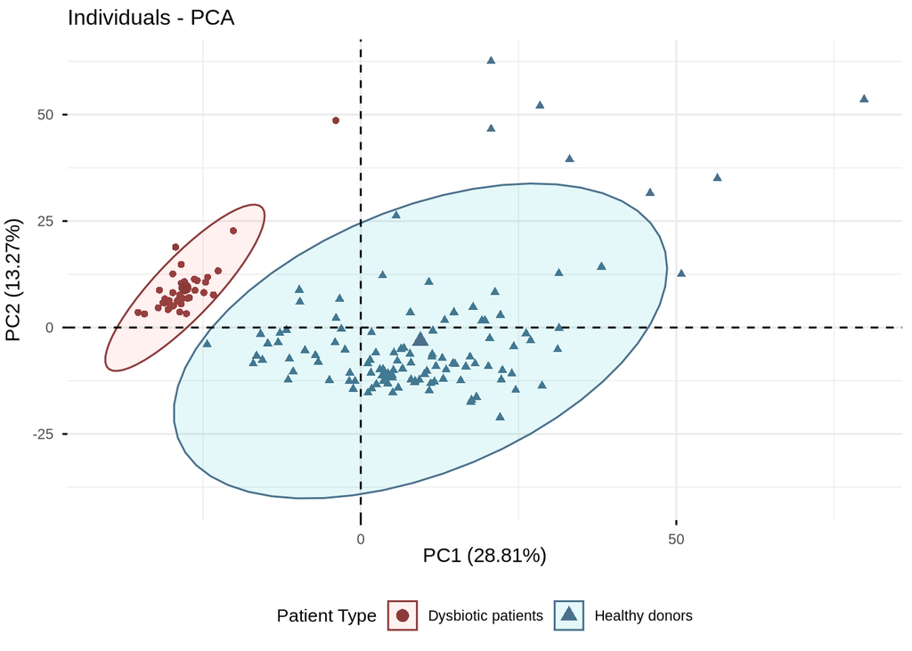

```r
#Plotting the PCA results with fviz_pca_ind (part of the factoextra package), uses ggplot2 internally
pca_sgk_regions_plot <- fviz_pca_ind(pca_skg_regions,
             label="none",
             habillage = 1, #Categorical data that separates results, here 'patient_type'
             addEllipses = TRUE,
             ellipse.level = 0.95,
             legend.title = "Patient Type",
             title = NULL,
             axes = c(1, 2), # Display PC1 and PC2
             xlab = paste0("PC1 (", round(pca_skg_regions$eig[1, 2], 2), "%)"), #PC1
             ylab = paste0("PC2 (", round(pca_skg_regions$eig[2, 2], 2), "%)")) + #PC2
  scale_colour_manual(values = c("Healthy donors" = "skyblue4", "Dysbiotic patients" = "indianred4")) +
  theme(text = element_text(size = 10),
        axis.title.y = element_text(vjust = +2, size = 11),
        axis.title.x = element_text(vjust = +2, size = 11),
        legend.position = "bottom",
        legend.box = "vertical",  # Stack legends vertically
        legend.text = element_text(size = rel(0.8)))

pca_sgk_regions_plot
```

```r
#ggsave("Figures_paper/Fig1A.PCA_regions.jpeg", width = 6, height = 4, units = "in", dpi = 600)
```

Scree plot Savitsky-Golay

The proportion of variances retained by the principal components can be extracted.

Eigenvalues: Correspond to the amount of the variation explained by each principal component (PC). Eigenvalues are large for the first PC and small for the subsequent PCs.

A PC with an eigenvalue > 1 indicates that the PC accounts for more variance than accounted by one of the original variables in standardized data. This is commonly used as a cutoff point to determine the number of PCs to retain.

```r
#Extract the eigenvalues
eigenvalues <- pca_skg_regions$eig
head(eigenvalues[, 1:2])
```

```
##        eigenvalue percentage of variance
## comp 1  453.25368              28.814601
## comp 2  208.70375              13.267880
## comp 3  119.17581               7.576339
## comp 4   71.02294               4.515127
## comp 5   63.64752               4.046250
## comp 6   53.59896               3.407435
```

```r
pca_skg_regions$eig
```

```
##            eigenvalue percentage of variance cumulative percentage of variance
## comp 1   4.532537e+02           2.881460e+01                          28.81460
## comp 2   2.087037e+02           1.326788e+01                          42.08248
## comp 3   1.191758e+02           7.576339e+00                          49.65882
## comp 4   7.102294e+01           4.515127e+00                          54.17395
## comp 5   6.364752e+01           4.046250e+00                          58.22020
## comp 6   5.359896e+01           3.407435e+00                          61.62763
## comp 7   3.847430e+01           2.445919e+00                          64.07355
## comp 8   3.525152e+01           2.241037e+00                          66.31459
## comp 9   2.730042e+01           1.735564e+00                          68.05015
## comp 10  2.416396e+01           1.536170e+00                          69.58632
## comp 11  2.098800e+01           1.334265e+00                          70.92059
## comp 12  2.058163e+01           1.308432e+00                          72.22902
## comp 13  1.919263e+01           1.220129e+00                          73.44915
## comp 14  1.778614e+01           1.130714e+00                          74.57986
## comp 15  1.655585e+01           1.052502e+00                          75.63236
## comp 16  1.558783e+01           9.909617e-01                          76.62333
## comp 17  1.437558e+01           9.138956e-01                          77.53722
## comp 18  1.373073e+01           8.729008e-01                          78.41012
## comp 19  1.322495e+01           8.407468e-01                          79.25087
## comp 20  1.268611e+01           8.064913e-01                          80.05736
## comp 21  1.176722e+01           7.480751e-01                          80.80544
## comp 22  1.117957e+01           7.107162e-01                          81.51615
## comp 23  1.090676e+01           6.933733e-01                          82.20953
## comp 24  1.001777e+01           6.368575e-01                          82.84638
## comp 25  9.541855e+00           6.066023e-01                          83.45299
## comp 26  8.989917e+00           5.715141e-01                          84.02450
## comp 27  8.870928e+00           5.639497e-01                          84.58845
## comp 28  8.583565e+00           5.456812e-01                          85.13413
## comp 29  8.209152e+00           5.218787e-01                          85.65601
## comp 30  7.703783e+00           4.897510e-01                          86.14576
## comp 31  7.456072e+00           4.740033e-01                          86.61976
## comp 32  7.246386e+00           4.606730e-01                          87.08044
## comp 33  7.158486e+00           4.550849e-01                          87.53552
## comp 34  6.939411e+00           4.411577e-01                          87.97668
## comp 35  6.509787e+00           4.138453e-01                          88.39052
## comp 36  6.339771e+00           4.030370e-01                          88.79356
## comp 37  6.065455e+00           3.855979e-01                          89.17916
## comp 38  5.798886e+00           3.686513e-01                          89.54781
## comp 39  5.667920e+00           3.603255e-01                          89.90814
```

[output cut: 99 more lines]

```
## comp 139 1.441362e-01           9.163141e-03                          99.92103
## comp 140 1.403678e-01           8.923576e-03                          99.92995
## comp 141 1.370297e-01           8.711359e-03                          99.93867
## comp 142 1.251121e-01           7.953725e-03                          99.94662
## comp 143 1.211299e-01           7.700567e-03                          99.95432
## comp 144 1.168161e-01           7.426323e-03                          99.96175
## comp 145 1.045733e-01           6.648017e-03                          99.96839
## comp 146 9.952015e-02           6.326774e-03                          99.97472
## comp 147 9.367043e-02           5.954890e-03                          99.98068
## comp 148 8.341799e-02           5.303114e-03                          99.98598
## comp 149 8.062570e-02           5.125600e-03                          99.99110
## comp 150 6.530870e-02           4.151856e-03                          99.99526
## comp 151 5.752795e-02           3.657212e-03                          99.99891
## comp 152 1.275995e-02           8.111857e-04                          99.99972
## comp 153 4.331812e-03           2.753854e-04                         100.00000
```

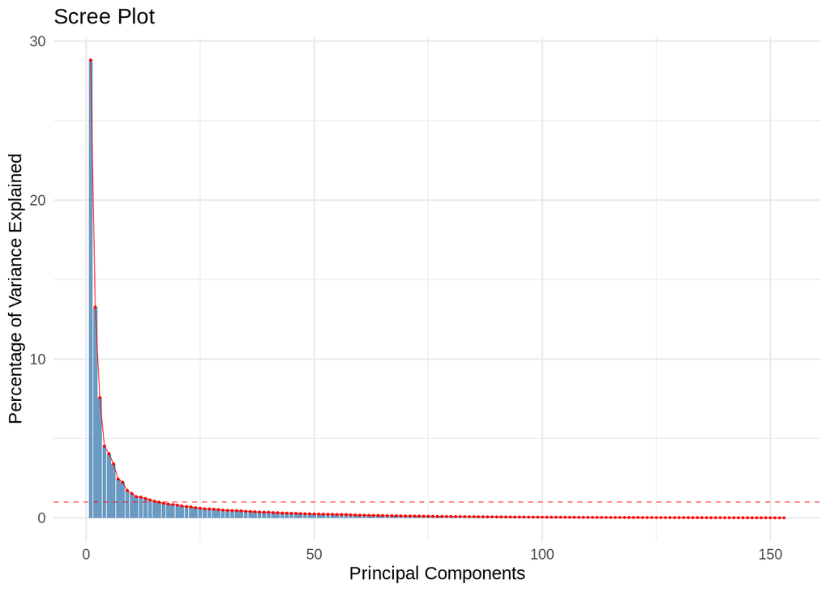

```r
#Convert to a dataframe
eigenvalues_df <- data.frame(principal_component = 1:nrow(eigenvalues),
  eigenvalues = eigenvalues[, 1],
  per_variance_explained = eigenvalues[, 2])

#Scree plot
scree_plot <- ggplot(eigenvalues_df, aes(x = principal_component, y = per_variance_explained)) +
  geom_bar(stat = "identity", fill = "steelblue", alpha = 0.8) +
  geom_line(aes(group = 1), color = "red", size = 0.2) +
  geom_point(color = "red", size = 0.2) +
  geom_hline(yintercept=1, linetype="dashed",color = "red", linewidth = 0.2) +
  labs(title = "Scree Plot",
    x = "Principal Components",
    y = "Percentage of Variance Explained") +
  theme_minimal()
scree_plot
```

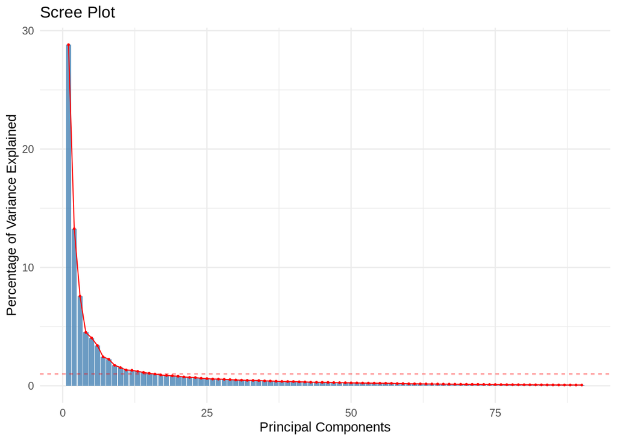

```r
#Scree plot of the fifty first PC
#Filter eigenvalue > 1 indicates that the PC accounts for more variance than accounted by one of the original variables in standardized data. This is commonly used as a cutoff point to determine the number of PCs to retain.eigenvalues_df_50 <- eigenvalues_df %>%

signif_eigenvalues <- eigenvalues_df[eigenvalues_df$eigenvalues >= 1, ]

scree_plot_signif <- ggplot(signif_eigenvalues, aes(x = principal_component, y = per_variance_explained)) +
  geom_bar(stat = "identity", fill = "steelblue", alpha = 0.8) +
  geom_line(aes(group = 1), color = "red", size = 0.4) +
  geom_point(color = "red", size = 0.4) +
  geom_hline(yintercept=1, linetype="dashed",color = "red", linewidth = 0.2) +
  labs(title = "Scree Plot",
    x = "Principal Components",
    y = "Percentage of Variance Explained") +
  theme_minimal()

scree_plot_signif
```

Contribution of variables (Supp Fig. S3)

The function fviz_contrib() creates a barplot of row/column contributions. A reference dashed line is also shown on the barplot. This reference line corresponds to the expected value if the contribution where uniform.

For a given dimension, any row/column with a contribution above the reference line could be considered as important in contributing to the dimension.

```r
#VARIABLE CONTRIBUTIONS
#Get the contribution of each variable to PC1 and PC2
var_contrib_reg <-as.data.frame(pca_skg_regions$var$contrib)  #Contributions of variables
nrow(var_contrib_reg)
```

```
## [1] 1573
```

```r
head(var_contrib_reg)  #Show the first variables
```

```
##            Dim.1       Dim.2      Dim.3      Dim.4        Dim.5
## 3600 0.051652029 0.021783144 0.13977683 0.15160920 1.843603e-06
## 3599 0.006945907 0.005263779 0.12508416 0.17526246 9.472964e-05
## 3598 0.019559439 0.005224106 0.01940128 0.04211251 7.293826e-03
## 3597 0.043567459 0.017234848 0.01246733 0.01186724 3.114719e-02
## 3596 0.028036150 0.011745535 0.04714373 0.07122288 4.708674e-02
## 3595 0.020619573 0.005870894 0.07058763 0.10658707 4.234918e-02
```

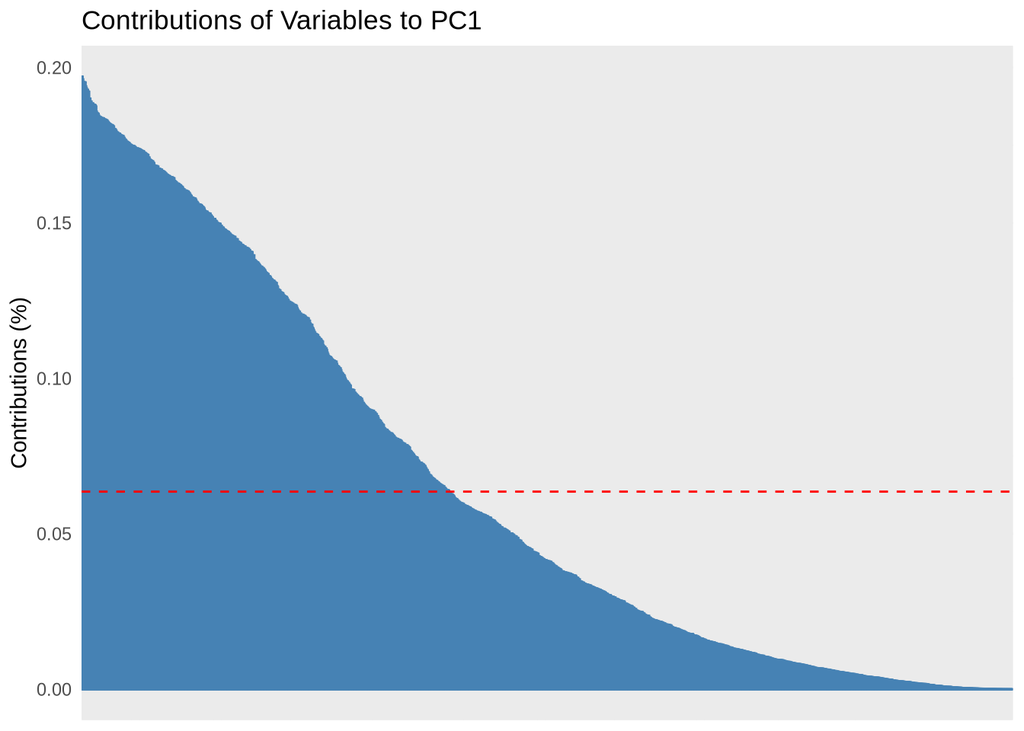

```r
#Visualizing Variable Contributions (1573 are all the variables used corresponding to the selected regions of SCFAs)

#PC1 - All variables
all_variables_PC1 <- fviz_contrib(pca_skg_regions, choice = "var", axes = 1, top = nrow(var_contrib_reg)) +  # Var. contrib. to PC1
  theme_minimal() +
  labs(title = "Contributions of Variables to PC1") +
  theme(axis.title.x = element_blank(), axis.text.x = element_blank())

all_variables_PC1
```

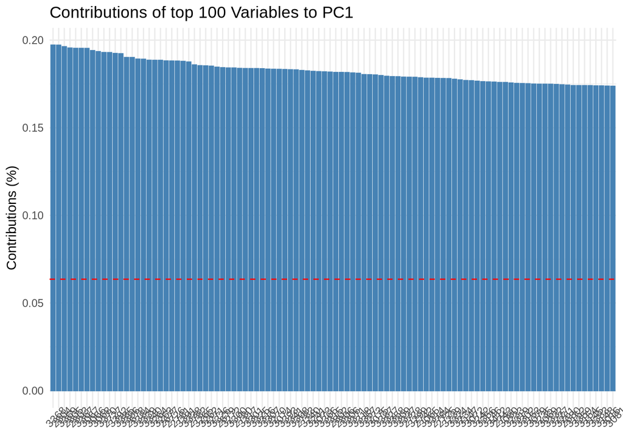

```r
#ggsave("Figures_paper/SupFigS3A.PC1_variables.jpeg", width = 6, height = 4, units = "in", dpi = 600)

#PC1 - First 100 Variable Contributions
top_variables_PC1 <- fviz_contrib(pca_skg_regions, choice = "var", axes = 1, top = 100) +
  theme_minimal() +
  labs(title = "Contributions of top 100 Variables to PC1") +
  theme(axis.title.x = element_blank(), axis.text.x = element_text(angle=45))

top_variables_PC1
```

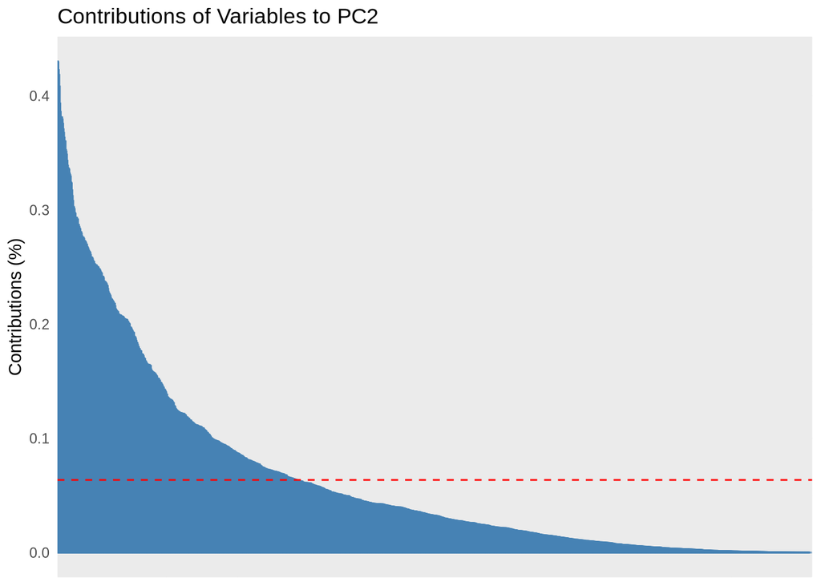

```r
#PC2 - All variables
all_variables_PC2 <- fviz_contrib(pca_skg_regions, choice = "var", axes = 2, top = nrow(var_contrib_reg)) +  # Var. contrib. to PC2
  theme_minimal() +
  labs(title = "Contributions of Variables to PC2") +
  theme(axis.title.x = element_blank(), axis.text.x = element_blank())

all_variables_PC2
```

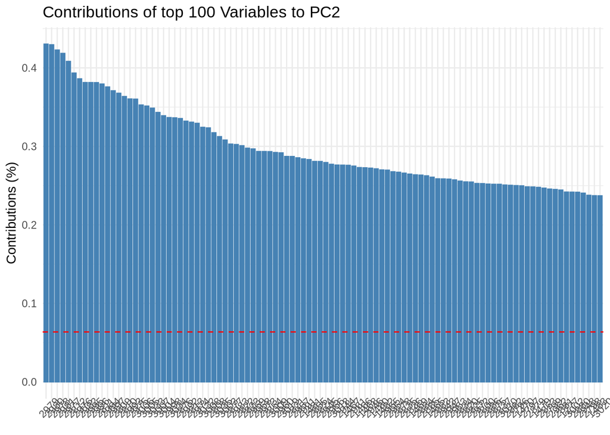

```r
#ggsave("Figures_paper/SupFigS3B.PC2_variables.jpeg", width = 6, height = 4, units = "in", dpi = 600)

#PC2 - First 100 Variable Contributions
top_variables_PC2 <- fviz_contrib(pca_skg_regions, choice = "var", axes = 2, top = 100) +
  theme_minimal() +
  labs(title = "Contributions of top 100 Variables to PC2") +
  theme(axis.title.x = element_blank(), axis.text.x = element_text(angle=45))

top_variables_PC2
```

Mahalanobis distance - Decision rule for dysbiosis screening

```r
#MAHALANOBIS DISTANCE - DECISION RULE FOR DYSBIOSIS SCREENING
#1. Select PCs to use
#Kaiser criterion (eigenvalue > 1), capped at ncp stored in the PCA object.
#PCA was run with ncp = 5, so ind$coord has at most 5 columns.
n_pcs_kaiser <- sum(pca_skg_regions$eig[, 1] > 1)
n_pcs_stored <- ncol(pca_skg_regions$ind$coord)
n_pcs <- min(n_pcs_kaiser, n_pcs_stored)

#We choose to use only the first 2 PCs for better visualization and interpretability, even if more PCs have eigenvalue > 1.
n_pcs <- 2
cat(sprintf("PCs with eigenvalue > 1: %d | PCs stored (ncp): %d | PCs used: %d\n",
            n_pcs_kaiser, n_pcs_stored, n_pcs))
```

```
## PCs with eigenvalue > 1: 90 | PCs stored (ncp): 5 | PCs used: 2
```

```r
#Extract PC scores for all samples
pca_scores <- as.data.frame(pca_skg_regions$ind$coord[, 1:n_pcs, drop = FALSE])
patient_type <- ir_filtered$patient_type

#2. Compute Mahalanobis distance to the healthy centroid
healthy_scores <- pca_scores[patient_type == "Healthy donors", , drop = FALSE]

#Centroid and covariance of the healthy group in PC space
healthy_centroid <- colMeans(healthy_scores)
healthy_cov      <- cov(healthy_scores)

#Mahalanobis distance for every sample to the healthy centroid
mahal_distances <- mahalanobis(pca_scores, center = healthy_centroid, cov = healthy_cov)

mahal_df <- data.frame(
  sample_id      = rownames(ir_filtered),
  mahal_distance = mahal_distances,
  patient_type   = patient_type,
  is_dysbiotic   = ifelse(patient_type == "Dysbiotic patients", 1, 0))
```

ROC analysis (Supp. Fig S8)

```r
#3. ROC analysis to find the optimal distance threshold
# direction = "<": lower distance → healthier → negative class
roc_obj <- roc(mahal_df$is_dysbiotic, mahal_df$mahal_distance,
               direction = "<", quiet = TRUE)

#Youden's J maximises sensitivity + specificity.
#For FMT screening, sensitivity is prioritised (avoid passing a dysbiotic donor).
cutoff_coords <- coords(roc_obj, "best", best.method = "youden",
                        ret = c("threshold", "sensitivity", "specificity", "accuracy"))

optimal_threshold   <- cutoff_coords$threshold
optimal_sensitivity <- cutoff_coords$sensitivity
optimal_specificity <- cutoff_coords$specificity

#4. Apply decision rule and report performance
mahal_df$prediction <- ifelse(mahal_df$mahal_distance < optimal_threshold,
                              "Healthy", "Dysbiotic")

confusion_matrix <- table(
  True      = ifelse(mahal_df$is_dysbiotic == 1, "Dysbiotic", "Healthy"),
  Predicted = mahal_df$prediction
)

overall_accuracy <- mean(mahal_df$prediction ==
                         ifelse(mahal_df$is_dysbiotic == 1, "Dysbiotic", "Healthy"))

cat("\n=== DYSBIOSIS SCREENING DECISION RULE SUMMARY ===\n")
```

```
##
## === DYSBIOSIS SCREENING DECISION RULE SUMMARY ===
```

```r
cat(sprintf("PCs used: %d  |  Optimal Mahalanobis threshold: %.3f\n",
            n_pcs, optimal_threshold))
```

```
## PCs used: 2  |  Optimal Mahalanobis threshold: 7.647
```

```r
cat(sprintf("Sensitivity : %.1f%%\n", optimal_sensitivity * 100))
```

```
## Sensitivity : 100.0%
```

```r
cat(sprintf("Specificity : %.1f%%\n", optimal_specificity * 100))
```

```
## Specificity : 94.8%
```

```r
cat(sprintf("Accuracy    : %.1f%%\n", overall_accuracy   * 100))
```

```
## Accuracy    : 96.1%
```

```r
cat(sprintf("AUC-ROC     : %.3f\n",   auc(roc_obj)))
```

```
## AUC-ROC     : 0.961
```

```r
cat("\nConfusion matrix:\n")
```

```
##
## Confusion matrix:
```

```r
print(confusion_matrix)
```

```
##            Predicted
## True        Dysbiotic Healthy
##   Dysbiotic        39       0
##   Healthy           6     109
```

```r
cat("\nDecision rule:\n")
```

```
##
## Decision rule:
```

```r
cat(sprintf("  Mahalanobis distance < %.3f  →  HEALTHY  (acceptable for FMT)\n", optimal_threshold))
```

```
##   Mahalanobis distance < 7.647  →  HEALTHY  (acceptable for FMT)
```

```r
cat(sprintf("  Mahalanobis distance >= %.3f  →  DYSBIOTIC (exclude from FMT)\n", optimal_threshold))
```

```
##   Mahalanobis distance >= 7.647  →  DYSBIOTIC (exclude from FMT)
```

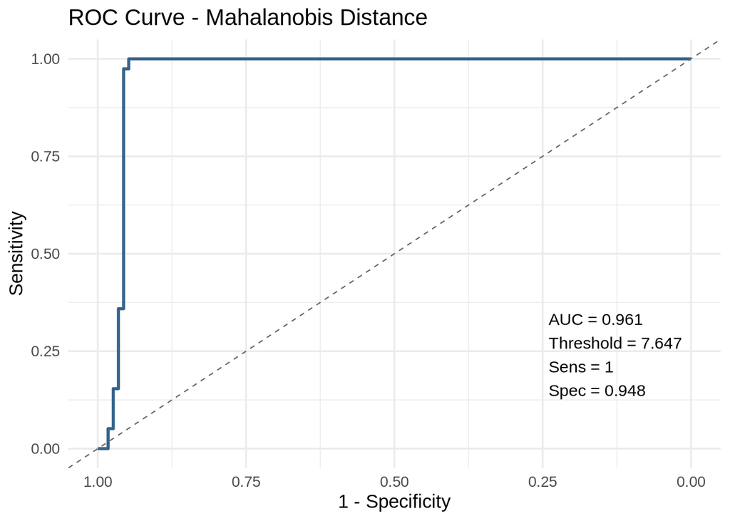

```r
#5. ROC curve plot
roc_plot <- ggroc(roc_obj, colour = "steelblue4", linewidth = 1) +
  geom_abline(intercept = 1, slope = 1,
              linetype = "dashed", colour = "grey40", linewidth = 0.4) +
  annotate("text", x = 0.24, y = 0.24,
           label = paste0("AUC = ",  round(auc(roc_obj), 3),
                          "\nThreshold = ", round(optimal_threshold, 3),
                          "\nSens = ",      round(optimal_sensitivity, 3),
                          "\nSpec = ",      round(optimal_specificity, 3)),
           size = 4, color = "black", hjust = 0) +
  labs(title = "ROC Curve - Mahalanobis Distance",
       x = "1 - Specificity", y = "Sensitivity") +
  theme_minimal(base_size = 13)

roc_plot
```

```r
#ggsave("Figures_paper/SupFigS8.ROC_Mahalanobis.jpeg", width = 6, height = 4, units = "in", dpi = 600)
```

PC scatter plot predicted class (Supp. Fig S9)

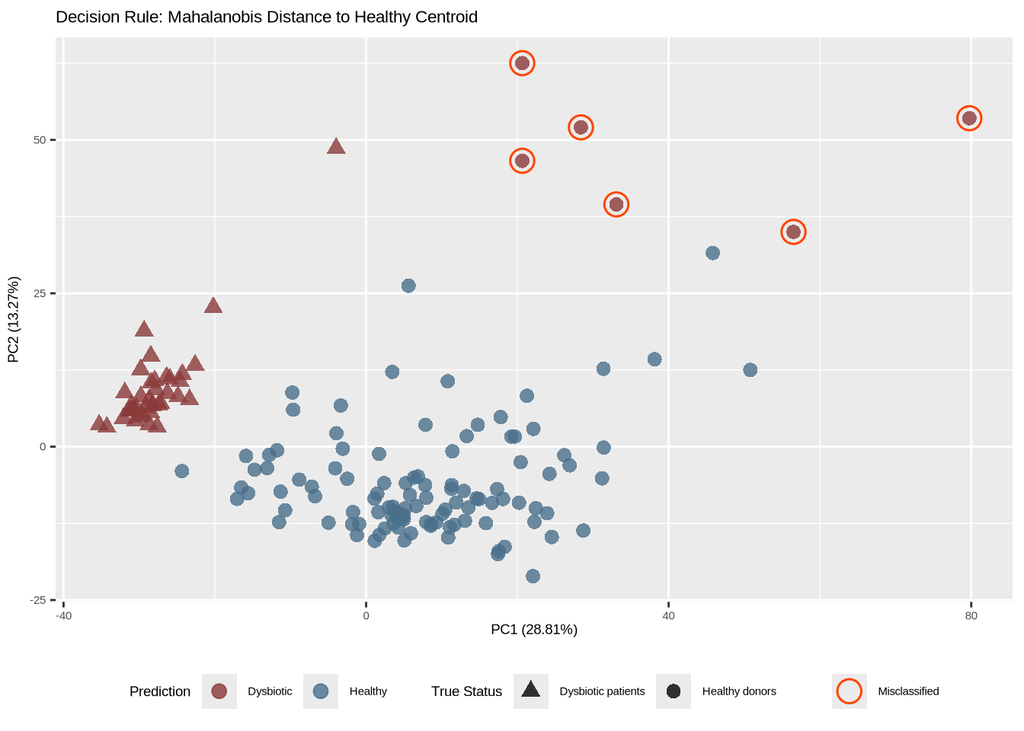

```r
#6. PC scatter plot coloured by predicted class
plot_df <- data.frame(
  PC1         = pca_scores[, 1],
  PC2         = pca_scores[, 2],
  true_status = patient_type,
  prediction  = mahal_df$prediction
)

plot_df$misclassified <- plot_df$prediction !=
  ifelse(plot_df$true_status == "Healthy donors", "Healthy", "Dysbiotic")

#Plot
decision_plot <- ggplot(plot_df,
                        aes(x = PC1, y = PC2,
                            colour = prediction, shape = true_status)) +
  geom_point(size = 3, alpha = 0.8) +
  geom_point(data = plot_df %>% filter(misclassified),
             aes(fill = "Misclassified"),
             shape = 21, size = 5, colour = "orangered",
             stroke = 0.8) +           # no alpha here
  scale_colour_manual(values = c("Healthy"   = "skyblue4",
                                 "Dysbiotic" = "indianred4")) +
  scale_shape_manual(values = c("Healthy donors"     = 16,
                                "Dysbiotic patients" = 17)) +
  scale_fill_manual(name = "", values = c("Misclassified" = "transparent")) +
  guides(colour = guide_legend(order = 1),
         shape  = guide_legend(order = 2),
         fill   = guide_legend(order = 3,
                               override.aes = list(colour  = "orangered",
                                                   shape   = 1,
                                                   size    = 5,
                                                   stroke  = 0.8,
                                                   fill    = NA))) +
  labs(x      = paste0("PC1 (", round(pca_skg_regions$eig[1, 2], 2), "%)"),
       y      = paste0("PC2 (", round(pca_skg_regions$eig[2, 2], 2), "%)"),
       title  = "Decision Rule: Mahalanobis Distance to Healthy Centroid",
       colour = "Prediction", shape = "True Status") +
  theme(text = element_text(size = 7),
        axis.title.y = element_text(vjust = +2, size = 7),
        axis.title.x = element_text(vjust = +2, size = 7),
        legend.position = "bottom",
        legend.text = element_text(size = rel(0.8)))

decision_plot
```

```r
#ggsave("Figures_paper/SupFigS9.Decision_plot.jpeg", width = 6, height = 4, units = "in", dpi = 600)
```

Spearman’s correlation: MD vs SCFAs

```r
#SCFA + FT-IR MAHALANOBIS DISTANCE SCORES
scfa_total <- rbind(scfa_hd, scfa_cdiff)
scfa_total <- scfa_total %>% remove_rownames %>% column_to_rownames(var='sample_id')

mahal_scfa <- merge(mahal_df, scfa_total, by = "row.names", all = FALSE) #Join by sample id, in this case is the row name
rownames(mahal_scfa) <- mahal_scfa$Row.names #Column "row.names" back to indeed row names
mahal_scfa <- mahal_scfa[, -1]  #Drop the Row.names column

#Correlation for between the Mahalanobis distance and each SCFAs
cor_acetate <- cor.test(mahal_scfa$mahal_distance, mahal_scfa$acetate, method = "spearman")
cor_propionate <- cor.test(mahal_scfa$mahal_distance, mahal_scfa$propionate,     method = "spearman")
cor_butyrate <- cor.test(mahal_scfa$mahal_distance, mahal_scfa$butyrate,     method = "spearman")
#Print correlation results
cat("\n--- Spearman correlations ---\n")
```

```
##
## --- Spearman correlations ---
```

```r
cat("Acetate vs MD:     rho =", cor_acetate$estimate,    "p =", cor_acetate$p.value, "\n")
```

```
## Acetate vs MD:     rho = -0.2439998 p = 0.002351046
```

```r
cat("Propionate vs MD:  rho =", cor_propionate$estimate, "p =", cor_propionate$p.value, "\n")
```

```
## Propionate vs MD:  rho = -0.3516896 p = 7.73035e-06
```

```r
cat("Butyrate vs MD:    rho =", cor_butyrate$estimate,   "p =", cor_butyrate$p.value, "\n")
```

```
## Butyrate vs MD:    rho = -0.3688512 p = 2.512854e-06
```

Scatter plots - SCFAs vs Mahalanobis

ACETATE (Supp. Fig S10A)

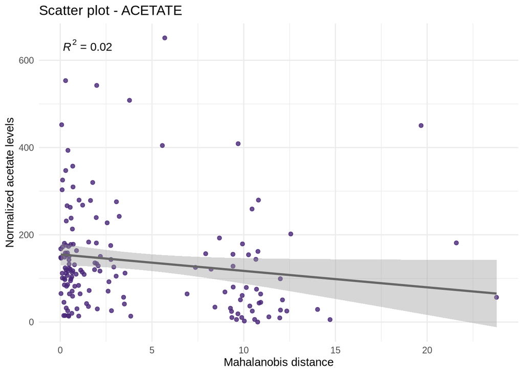

```r
#SCFA vs Mahalanobis (df = mahal_scfa) - ACETATE
#Scatter plot - ACETATE
scatter_plot_acetate <- ggplot(mahal_scfa, aes(x = mahal_distance, y = acetate)) +
  geom_point(color = "#482677FF", alpha = 0.8) +
  geom_smooth(method = "lm", color="gray40", fill="gray60", formula = y ~ x, se=TRUE) +
  stat_poly_eq() +
  labs(title="Scatter plot - ACETATE",
        x ="Mahalanobis distance", y = "Normalized acetate levels") +
  theme_minimal()

scatter_plot_acetate
```

```r
#ggsave("Figures_paper/SupFigS10A.Scatter_acetate.jpeg", width = 6, height = 4, units = "in", dpi = 600)
```

PROPIONATE (Supp. Fig S10B)

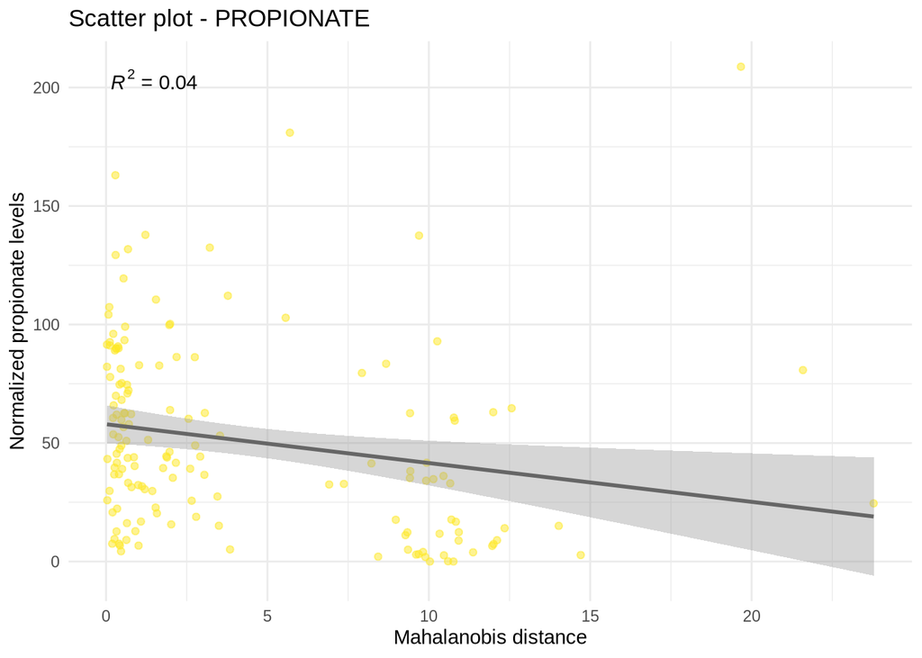

```r
#SCFA vs Mahalanobis (df = mahal_scfa) - PROPIONATE
#Scatter plot - PROPIONATE
scatter_plot_propionate <- ggplot(mahal_scfa, aes(x = mahal_distance, y = propionate)) +
  geom_point(color = "#FDE725FF", alpha = 0.5) +
  geom_smooth(method = "lm", color="gray40", fill="gray60", formula = y ~ x, se=TRUE) +
  stat_poly_eq() +
  labs(title="Scatter plot - PROPIONATE",
        x ="Mahalanobis distance", y = "Normalized propionate levels") +
  theme_minimal()

scatter_plot_propionate
```

```r
#ggsave("Figures_paper/SupFigS10B.Scatter_propionate.jpeg", width = 6, height = 4, units = "in", dpi = 600)
```

BUTYRATE (Supp. Fig S10C)

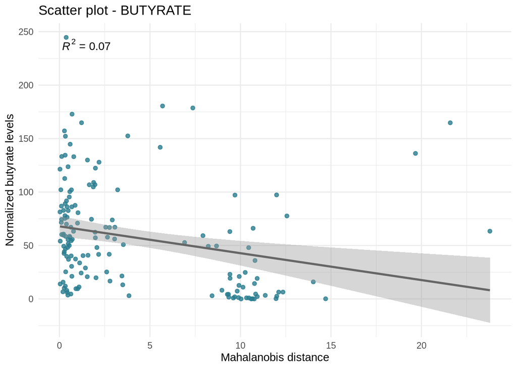

```r
#SCFA vs Mahalanobis (df = mahal_scfa) - BUTYRATE
#Scatter plot - BUTYRATE
scatter_plot_butyrate <- ggplot(mahal_scfa, aes(x = mahal_distance, y = butyrate)) +
  geom_point(color = "#287C8EFF", alpha = 0.8) +
  geom_smooth(method = "lm", color="gray40", fill="gray60", formula = y ~ x, se=TRUE) +
  stat_poly_eq() +
  labs(title="Scatter plot - BUTYRATE",
        x ="Mahalanobis distance", y = "Normalized butyrate levels") +
  theme_minimal()

scatter_plot_butyrate
```

```r
#ggsave("Figures_paper/SupFigS10C.Scatter_butyrate.jpeg", width = 6, height = 4, units = "in", dpi = 600)
```

LDA nested LOOCV + Bootstrap confidence intervals

KEY DESIGN DECISIONS:

Nested LOOCV: PCA is recomputed from scratch on N-1 training samples each fold. The left-out sample is projected onto the TRAINING PCA space. —> This eliminates data leakage compared to the approach where we just remove the data point sample from the PCA calculations.

Bootstrap CI (B=1000): each re-sample runs the full PCA+LDA pipeline on the bootstrap sample and evaluates on out-of-bag (OOB) samples. —> This directly addresses sample-composition robustness.

Equal priors (0.5/0.5) throughout to correct for 25/75 class imbalance.

```r
#LDA - NESTED LOOCV + BOOTSTRAP CI

#Input: raw spectral matrix (no patient_type column) + labels
#We use ir_filtered directly so that PCA is refit inside each fold/bootstrap
spectral_data <- as.matrix(ir_filtered[, -1])   # drop patient_type column
patient_type  <- ir_filtered$patient_type
group_factor  <- factor(patient_type)
n_samples     <- nrow(spectral_data)

cat("Class distribution:\n")
```

```
## Class distribution:
```

```r
print(table(group_factor))
```

```
## group_factor
## Dysbiotic patients     Healthy donors
##                 39                115
```

```r
#Helper: given train/test spectral matrices + labels, fit PCA+LDA and return
#P(Dysbiotic) for each test sample. npc = number of PCs to retain.
run_pca_lda <- function(train_X, test_X, train_y, npc) {
  #PCA on training data only
  pca_fit    <- prcomp(train_X, center = TRUE, scale. = TRUE)
  train_pcs  <- as.data.frame(pca_fit$x[, 1:npc, drop = FALSE])
  test_pcs   <- as.data.frame(predict(pca_fit, newdata = test_X)[, 1:npc, drop = FALSE])

  train_df   <- data.frame(train_pcs, group = train_y)

  lda_fit    <- lda(group ~ ., data = train_df, prior = c(0.5, 0.5))
  lda_pred   <- predict(lda_fit, newdata = test_pcs)

  list(
    prob  = lda_pred$posterior[, "Dysbiotic patients"],
    class = as.character(lda_pred$class)
  )
}

#Number of PCs: use Kaiser criterion on the FULL PCA (for reference),
#capped at ncp=5 stored in the existing pca_skg_regions object.
#Inside each fold prcomp retains all components; we slice to npc.
npc <- min(sum(pca_skg_regions$eig[, 1] > 1), 5)
cat(sprintf("\nPCs used in nested CV: %d\n", npc))
```

```
##
## PCs used in nested CV: 5
```

```r
#1. NESTED LOOCV
loocv_probs  <- numeric(n_samples)
loocv_labels <- character(n_samples)

for (i in seq_len(n_samples)) {
  train_X <- spectral_data[-i, , drop = FALSE]
  test_X  <- spectral_data[ i, , drop = FALSE]
  train_y <- group_factor[-i]

  res <- run_pca_lda(train_X, test_X, train_y, npc)
  loocv_probs[i]  <- res$prob
  loocv_labels[i] <- res$class
}

loocv_labels <- factor(loocv_labels, levels = levels(group_factor))

#Performance
cm_loocv <- confusionMatrix(loocv_labels, group_factor,
                             positive = "Dysbiotic patients")
roc_loocv <- roc(ifelse(group_factor == "Dysbiotic patients", 1, 0),
                 loocv_probs, direction = "<", quiet = TRUE)

#MCC
tp <- cm_loocv$table["Dysbiotic patients", "Dysbiotic patients"]
tn <- cm_loocv$table["Healthy donors",     "Healthy donors"]
fp <- cm_loocv$table["Dysbiotic patients", "Healthy donors"]
fn <- cm_loocv$table["Healthy donors",     "Dysbiotic patients"]
mcc_num <- (tp * tn) - (fp * fn)
mcc_den <- sqrt((tp + fp) * (tp + fn) * (tn + fp) * (tn + fn))
mcc_obs <- ifelse(mcc_den == 0, 0, mcc_num / mcc_den)

cat("\n=== NESTED LOOCV PERFORMANCE (no data leakage) ===\n")
```

```
##
## === NESTED LOOCV PERFORMANCE (no data leakage) ===
```

```r
cat(sprintf("AUROC             : %.3f\n",  as.numeric(auc(roc_loocv))))
```

```
## AUROC             : 1.000
```

```r
cat(sprintf("Sensitivity       : %.1f%%\n", cm_loocv$byClass["Sensitivity"]       * 100))
```

```
## Sensitivity       : 100.0%
```

```r
cat(sprintf("Specificity       : %.1f%%\n", cm_loocv$byClass["Specificity"]       * 100))
```

```
## Specificity       : 99.1%
```

```r
cat(sprintf("Balanced Accuracy : %.1f%%\n", cm_loocv$byClass["Balanced Accuracy"] * 100))
```

```
## Balanced Accuracy : 99.6%
```

```r
cat(sprintf("MCC               : %.3f\n",  mcc_obs))
```

```
## MCC               : 0.983
```

```r
cat("\nConfusion matrix:\n")
```

```
##
## Confusion matrix:
```

```r
print(cm_loocv$table)
```

```
##                     Reference
## Prediction           Dysbiotic patients Healthy donors
##   Dysbiotic patients                 39              1
##   Healthy donors                      0            114
```

ROC plot - Nested LOOCV (Supp. Fig S11)

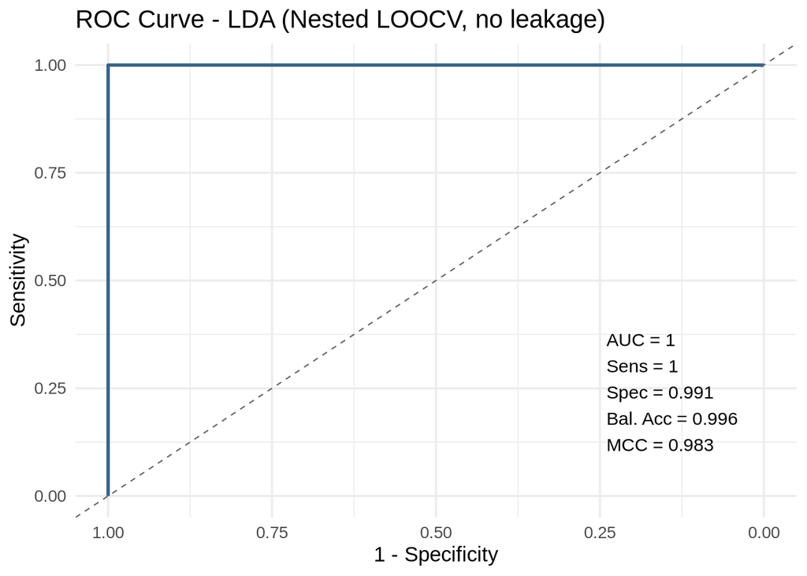

```r
#ROC plot — nested LOOCV
roc_nested_plot <- ggroc(roc_loocv, colour = "steelblue4", linewidth = 1) +
  geom_abline(intercept = 1, slope = 1,
              linetype = "dashed", colour = "grey40", linewidth = 0.4) +
  annotate("text", x = 0.24, y = 0.24,
           label = paste0("AUC = ",            round(auc(roc_loocv), 3),
                          "\nSens = ",         round(cm_loocv$byClass["Sensitivity"],       3),
                          "\nSpec = ",         round(cm_loocv$byClass["Specificity"],       3),
                          "\nBal. Acc = ",     round(cm_loocv$byClass["Balanced Accuracy"], 3),
                          "\nMCC = ",          round(mcc_obs, 3)),
           size = 4, colour = "black", hjust = 0) +
  labs(title = "ROC Curve - LDA (Nested LOOCV, no leakage)",
       x = "1 - Specificity", y = "Sensitivity") +
  theme_minimal(base_size = 13)

roc_nested_plot
```

```r
#ggsave("Figures_paper/SupFigS11.ROC_LOOCV-LDA.jpeg", width = 6, height = 4, units = "in", dpi = 600)
```

Bootstrap (Supp. Fig. S12 and S13)

```r
#2. BOOTSTRAP CONFIDENCE INTERVALS (B = 1000)
# Each bootstrap iteration:
#   a) Sample N indices WITH replacement -> bootstrap sample
#   b) Out-of-bag (OOB) = samples NOT selected (typically ~37% of N)
#   c) Fit PCA + LDA on bootstrap sample
#   d) Predict on OOB samples -> compute metrics
# This tests robustness to different sample compositions.

set.seed(123)
B <- 1000

boot_auc   <- numeric(B)
boot_sens  <- numeric(B)
boot_spec  <- numeric(B)
boot_bacc  <- numeric(B)
boot_mcc   <- numeric(B)

valid_boots <- 0  # count iterations with usable OOB sets

for (b in seq_len(B)) {
  boot_idx <- sample(seq_len(n_samples), replace = TRUE)
  oob_idx  <- setdiff(seq_len(n_samples), boot_idx)

  # Skip if OOB has fewer than 2 samples or missing a class
  if (length(oob_idx) < 2) next
  oob_classes <- group_factor[oob_idx]
  if (length(unique(oob_classes)) < 2) next

  train_X <- spectral_data[boot_idx, , drop = FALSE]
  test_X  <- spectral_data[oob_idx,  , drop = FALSE]
  train_y <- group_factor[boot_idx]

  res <- tryCatch(
    run_pca_lda(train_X, test_X, train_y, npc),
    error = function(e) NULL
  )
  if (is.null(res)) next

  pred_labels_b <- factor(res$class, levels = levels(group_factor))
  true_labels_b <- oob_classes

  cm_b <- tryCatch(
    confusionMatrix(pred_labels_b, true_labels_b, positive = "Dysbiotic patients"),
    error = function(e) NULL
  )
  if (is.null(cm_b)) next

  roc_b <- tryCatch(
    roc(ifelse(true_labels_b == "Dysbiotic patients", 1, 0),
        res$prob, direction = "<", quiet = TRUE),
    error = function(e) NULL
  )
  if (is.null(roc_b)) next

  tp_b <- cm_b$table["Dysbiotic patients", "Dysbiotic patients"]
  tn_b <- cm_b$table["Healthy donors",     "Healthy donors"]
  fp_b <- cm_b$table["Dysbiotic patients", "Healthy donors"]
  fn_b <- cm_b$table["Healthy donors",     "Dysbiotic patients"]
  den_b <- sqrt((tp_b + fp_b) * (tp_b + fn_b) * (tn_b + fp_b) * (tn_b + fn_b))

  valid_boots <- valid_boots + 1
  boot_auc[valid_boots]  <- as.numeric(auc(roc_b))
  boot_sens[valid_boots] <- cm_b$byClass["Sensitivity"]
  boot_spec[valid_boots] <- cm_b$byClass["Specificity"]
  boot_bacc[valid_boots] <- cm_b$byClass["Balanced Accuracy"]
  boot_mcc[valid_boots]  <- ifelse(den_b == 0, 0,
                                   ((tp_b * tn_b) - (fp_b * fn_b)) / den_b)
}

# Trim to valid iterations
boot_auc   <- boot_auc[1:valid_boots]
boot_sens  <- boot_sens[1:valid_boots]
boot_spec  <- boot_spec[1:valid_boots]
boot_bacc  <- boot_bacc[1:valid_boots]
boot_mcc   <- boot_mcc[1:valid_boots]

ci95 <- function(x) quantile(x, c(0.025, 0.975), na.rm = TRUE)

cat(sprintf("\n=== BOOTSTRAP CONFIDENCE INTERVALS (B = %d valid resamples) ===\n",
            valid_boots))
```

```
##
## === BOOTSTRAP CONFIDENCE INTERVALS (B = 1000 valid resamples) ===
```

```r
cat(sprintf("AUROC             : %.3f  [%.3f - %.3f]\n",
            median(boot_auc),  ci95(boot_auc)[1],  ci95(boot_auc)[2]))
```

```
## AUROC             : 1.000  [0.984 - 1.000]
```

```r
cat(sprintf("Sensitivity       : %.3f  [%.3f - %.3f]\n",
            median(boot_sens), ci95(boot_sens)[1], ci95(boot_sens)[2]))
```

```
## Sensitivity       : 1.000  [1.000 - 1.000]
```

```r
cat(sprintf("Specificity       : %.3f  [%.3f - %.3f]\n",
            median(boot_spec), ci95(boot_spec)[1], ci95(boot_spec)[2]))
```

```
## Specificity       : 1.000  [0.929 - 1.000]
```

```r
cat(sprintf("Balanced Accuracy : %.3f  [%.3f - %.3f]\n",
            median(boot_bacc), ci95(boot_bacc)[1], ci95(boot_bacc)[2]))
```

```
## Balanced Accuracy : 1.000  [0.963 - 1.000]
```

```r
cat(sprintf("MCC               : %.3f  [%.3f - %.3f]\n",
            median(boot_mcc),  ci95(boot_mcc)[1],  ci95(boot_mcc)[2]))
```

```
## MCC               : 1.000  [0.867 - 1.000]
```

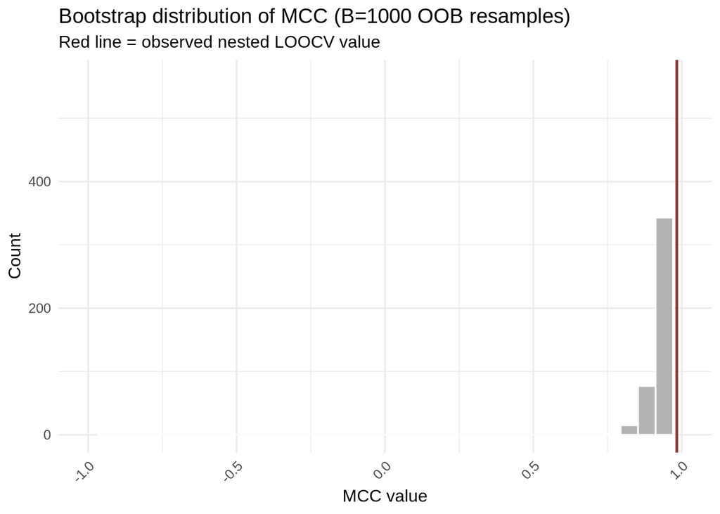

```r
# Bootstrap distribution plots
boot_results_df <- data.frame(
  AUC              = boot_auc,
  Sensitivity      = boot_sens,
  Specificity      = boot_spec,
  Balanced_Accuracy = boot_bacc,
  MCC              = boot_mcc
)

boot_long <- pivot_longer(boot_results_df, everything(),
                          names_to = "metric", values_to = "value")

# Observed values for vertical reference lines
obs_vals <- data.frame(
  metric = c("AUC", "Sensitivity", "Specificity", "Balanced_Accuracy", "MCC"),
  obs    = c(as.numeric(auc(roc_loocv)),
             cm_loocv$byClass["Sensitivity"],
             cm_loocv$byClass["Specificity"],
             cm_loocv$byClass["Balanced Accuracy"],
             mcc_obs)
)

# Boot_plot of MCC
boot_long_mcc <- boot_long %>% filter(metric == "MCC")
obs_vals_mcc <- obs_vals %>% filter(metric == "MCC")

# MCC range is from -1 to 1, so we adjust x-axis limits for better visualization
boot_plot_mcc <- ggplot(boot_long_mcc, aes(x = value)) +
  geom_histogram(bins = 35, fill = "grey70", colour = "white") +
  geom_vline(data = obs_vals_mcc, aes(xintercept = obs),
             colour = "indianred4", linewidth = 0.9, linetype = "solid") +
  scale_x_continuous(limits = c(-1, 1)) +  # Set x-axis limits from -1 to 1
  labs(title = "Bootstrap distribution of MCC (B=1000 OOB resamples)",
       subtitle = "Red line = observed nested LOOCV value",
       x = "MCC value", y = "Count") +
  theme_minimal(base_size = 12) +
  theme(strip.text = element_text(face = "bold"),
        axis.text.x = element_text(angle = 45, hjust = 1))

boot_plot_mcc
```

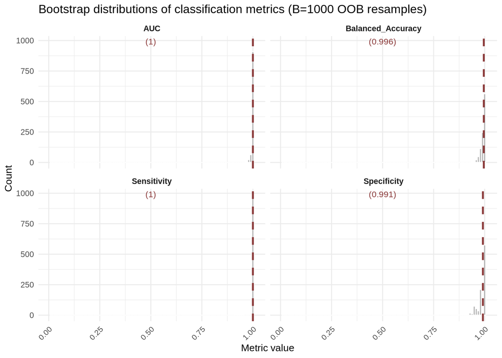

```r
#ggsave("Figures_paper/SupFigS12.Distribution_boot_MCC.jpeg", width = 6, height = 4, units = "in", dpi = 600)

# Updated boot_plot without MCC
boot_long_no_mcc <- boot_long %>% filter(metric != "MCC")
obs_vals_no_mcc <- obs_vals %>% filter(metric != "MCC")

boot_plot <- ggplot(boot_long_no_mcc, aes(x = value)) +
  geom_histogram(bins = 100, fill = "grey70", colour = "white") +
  geom_vline(data = obs_vals_no_mcc, aes(xintercept = obs),
             colour = "indianred4", linewidth = 0.9, linetype = "dashed") +
  geom_text(data = obs_vals_no_mcc, aes(x = 0.5, y = Inf, label = paste0("(", round(obs, 3), ")")),
            vjust = 1.5, hjust = 0.5, size = 3, colour = "indianred4", inherit.aes = FALSE) +
  scale_x_continuous(limits = c(0, 1.01)) +  # Set x-axis limits from 0 to 1
  facet_wrap(~ metric, ncol = 2) +
  labs(title = paste0("Bootstrap distributions of classification ",
                      "metrics (B=1000 OOB resamples)"),
       x = "Metric value", y = "Count") +
  theme_minimal(base_size = 10) +
  theme(strip.text = element_text(face = "bold"),
        axis.text.x = element_text(angle = 45, hjust = 1))

boot_plot
```

```r
#ggsave("Figures_paper/SupFigS13.Distribution_boot_metrics.jpeg", width = 6, height = 4, units = "in", dpi = 600)
```

PCA - All regions (Supp. Fig. S2)

```r
#Merge data from Savitzky-Golay (2nd derivate)
#For the PCA analysis we need a single dataframe with n rows (individuals) and p columns (numeric variables)
ir_skg_total <- rbind(ir_healthy_skg, ir_cdiff_sgk) %>%
  mutate(patient_type = rep(c("Healthy donors", "Dysbiotic patients"), times = c(115, 39))) %>%
  dplyr::select(patient_type, everything()) # Places `patient_type` at the begining

#PCA
#The variable 'patient_type' (column = 1) is removed before the PCA analysis
pca_skg <- PCA(ir_skg_total, ncp = 5, scale = TRUE, quali.sup = 1)
```

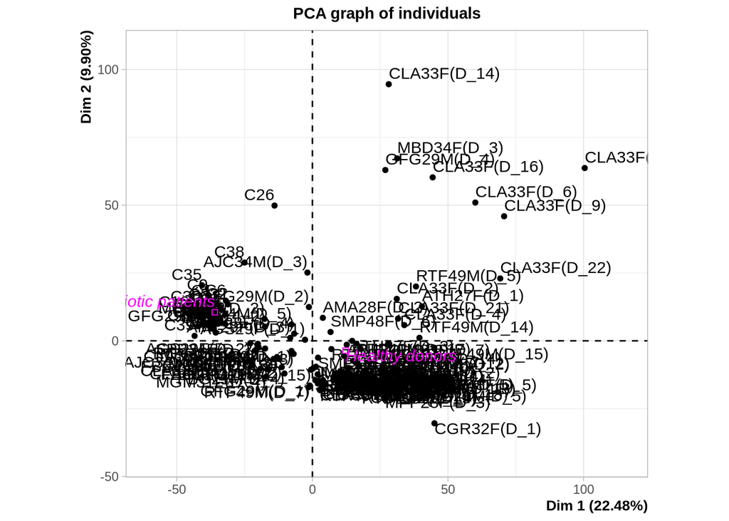

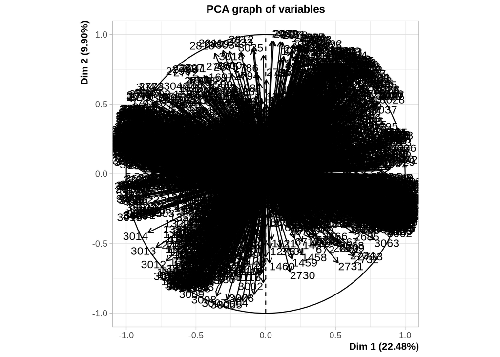

```r
#OUTPUTS PCA
summary(pca_skg)  #Summary of PCA
```

```
##
## Call:
## PCA(X = ir_skg_total, scale.unit = TRUE, ncp = 5, quali.sup = 1)
##
##
## Eigenvalues
##                        Dim.1   Dim.2   Dim.3   Dim.4   Dim.5   Dim.6   Dim.7
## Variance             784.501 345.327 177.661 154.915 134.027 100.878  88.640
## % of var.             22.485   9.898   5.092   4.440   3.841   2.891   2.541
## Cumulative % of var.  22.485  32.383  37.475  41.915  45.756  48.647  51.188
##                        Dim.8   Dim.9  Dim.10  Dim.11  Dim.12  Dim.13  Dim.14
## Variance              81.678  69.948  62.412  60.490  55.795  47.072  45.044
## % of var.              2.341   2.005   1.789   1.734   1.599   1.349   1.291
## Cumulative % of var.  53.529  55.534  57.323  59.056  60.656  62.005  63.296
##                       Dim.15  Dim.16  Dim.17  Dim.18  Dim.19  Dim.20  Dim.21
## Variance              44.754  39.544  38.010  36.854  34.998  33.767  31.745
## % of var.              1.283   1.133   1.089   1.056   1.003   0.968   0.910
## Cumulative % of var.  64.578  65.712  66.801  67.858  68.861  69.828  70.738
##                       Dim.22  Dim.23  Dim.24  Dim.25  Dim.26  Dim.27  Dim.28
## Variance              30.731  30.614  28.799  26.465  23.900  23.152  23.100
## % of var.              0.881   0.877   0.825   0.759   0.685   0.664   0.662
## Cumulative % of var.  71.619  72.497  73.322  74.080  74.766  75.429  76.091
##                       Dim.29  Dim.30  Dim.31  Dim.32  Dim.33  Dim.34  Dim.35
## Variance              22.472  22.117  21.759  20.897  20.551  19.627  19.395
## % of var.              0.644   0.634   0.624   0.599   0.589   0.563   0.556
## Cumulative % of var.  76.735  77.369  77.993  78.592  79.181  79.743  80.299
##                       Dim.36  Dim.37  Dim.38  Dim.39  Dim.40  Dim.41  Dim.42
## Variance              19.262  18.437  17.729  17.309  17.123  16.442  15.945
## % of var.              0.552   0.528   0.508   0.496   0.491   0.471   0.457
## Cumulative % of var.  80.851  81.380  81.888  82.384  82.875  83.346  83.803
##                       Dim.43  Dim.44  Dim.45  Dim.46  Dim.47  Dim.48  Dim.49
## Variance              15.790  14.718  14.335  14.221  13.868  13.289  12.807
## % of var.              0.453   0.422   0.411   0.408   0.397   0.381   0.367
## Cumulative % of var.  84.256  84.677  85.088  85.496  85.893  86.274  86.641
##                       Dim.50  Dim.51  Dim.52  Dim.53  Dim.54  Dim.55  Dim.56
## Variance              12.476  12.461  12.128  12.018  11.725  11.552  11.134
## % of var.              0.358   0.357   0.348   0.344   0.336   0.331   0.319
## Cumulative % of var.  86.999  87.356  87.704  88.048  88.384  88.715  89.034
##                       Dim.57  Dim.58  Dim.59  Dim.60  Dim.61  Dim.62  Dim.63
## Variance              10.806  10.474  10.161  10.056   9.427   9.275   9.268
```

[output cut: 95 more lines]

```
## 3989                0.000  0.000 |
## 3988                0.004  0.007 |
## 3987                0.009  0.016 |
## 3986                0.006  0.011 |
## 3985                0.001  0.002 |
## 3984                0.000  0.000 |
## 3983                0.006  0.011 |
##
## Supplementary categories
##                         Dist     Dim.1    cos2  v.test     Dim.2    cos2
## Dysbiotic patients |  38.759 | -36.006   0.863  -9.260 |  10.524   0.074
## Healthy donors     |  13.144 |  12.211   0.863   9.260 |  -3.569   0.074
##                     v.test     Dim.3    cos2  v.test
## Dysbiotic patients   4.079 |  -7.303   0.036  -3.947 |
## Healthy donors      -4.079 |   2.477   0.036   3.947 |
```

```r
#Eigenvalues --> a matrix containing all the eigenvalues, the percentage of variance and the cumulative percentage of variance
pca_skg$eig
```

```
##            eigenvalue percentage of variance cumulative percentage of variance
## comp 1   784.50094255           22.484979723                          22.48498
## comp 2   345.32682286            9.897587356                          32.38257
## comp 3   177.66141826            5.092044089                          37.47461
## comp 4   154.91507407            4.440099572                          41.91471
## comp 5   134.02730559            3.841424637                          45.75614
## comp 6   100.87838305            2.891326542                          48.64746
## comp 7    88.64008923            2.540558591                          51.18802
## comp 8    81.67830512            2.341023362                          53.52904
## comp 9    69.94819396            2.004820693                          55.53386
## comp 10   62.41184603            1.788817599                          57.32268
## comp 11   60.48970039            1.733726007                          59.05641
## comp 12   55.79487339            1.599165187                          60.65557
## comp 13   47.07154446            1.349141429                          62.00471
## comp 14   45.04412399            1.291032502                          63.29575
## comp 15   44.75404657            1.282718446                          64.57847
## comp 16   39.54396313            1.133389599                          65.71186
## comp 17   38.00964727            1.089413794                          66.80127
## comp 18   36.85352823            1.056277679                          67.85755
## comp 19   34.99794594            1.003093893                          68.86064
## comp 20   33.76686846            0.967809357                          69.82845
## comp 21   31.74500194            0.909859614                          70.73831
## comp 22   30.73082017            0.880791636                          71.61910
## comp 23   30.61354192            0.877430264                          72.49653
## comp 24   28.79907697            0.825424963                          73.32196
## comp 25   26.46520919            0.758532794                          74.08049
## comp 26   23.90040513            0.685021643                          74.76551
## comp 27   23.15166342            0.663561577                          75.42907
## comp 28   23.09957785            0.662068726                          76.09114
## comp 29   22.47246458            0.644094714                          76.73524
## comp 30   22.11651741            0.633892732                          77.36913
## comp 31   21.75901589            0.623646199                          77.99277
## comp 32   20.89650640            0.598925377                          78.59170
## comp 33   20.55095610            0.589021384                          79.18072
## comp 34   19.62746976            0.562552874                          79.74327
## comp 35   19.39505659            0.555891562                          80.29917
## comp 36   19.26180976            0.552072507                          80.85124
## comp 37   18.43731811            0.528441333                          81.37968
## comp 38   17.72922546            0.508146330                          81.88783
## comp 39   17.30884842            0.496097690                          82.38392
```

[output cut: 99 more lines]

```
## comp 139   1.13626378            0.032567033                          99.72392
## comp 140   1.05065986            0.030113496                          99.75404
## comp 141   1.02497179            0.029377237                          99.78341
## comp 142   0.96331058            0.027609934                          99.81102
## comp 143   0.94155899            0.026986500                          99.83801
## comp 144   0.87951402            0.025208198                          99.86322
## comp 145   0.83657292            0.023977441                          99.88720
## comp 146   0.79620343            0.022820391                          99.91002
## comp 147   0.72246071            0.020706813                          99.93072
## comp 148   0.66860552            0.019163242                          99.94989
## comp 149   0.59353938            0.017011733                          99.96690
## comp 150   0.56404290            0.016166320                          99.98306
## comp 151   0.47091537            0.013497145                          99.99656
## comp 152   0.07948791            0.002278243                          99.99884
## comp 153   0.04050305            0.001160879                         100.00000
```

```r
#Coordinates (loadings) --> a list of matrices containing all the results for the active variables (coordinates, correlation between variables and axes, square cosine, contributions)
pca_skg$var$coord
```

```
##              Dim.1         Dim.2         Dim.3         Dim.4         Dim.5
## 3992  0.7268750223 -1.711165e-01 -7.008150e-02 -1.222171e-01 -1.196271e-02
## 3991  0.6896614658 -1.810602e-01 -1.010716e-01 -3.479374e-02  4.267529e-02
## 3990  0.5704084161 -1.555771e-01 -8.370478e-02  2.870548e-02  8.806729e-02
## 3989  0.2972624474 -7.492027e-02 -1.127121e-02  8.172459e-02  1.240239e-01
## 3988 -0.1843952301  6.824516e-02  8.403097e-02  1.379880e-01  1.248371e-01
## 3987 -0.5602395632  1.779317e-01  1.270665e-01  1.500275e-01  7.937399e-02
## 3986 -0.7136429858  2.172101e-01  1.042757e-01  1.567152e-01  3.905618e-02
## 3985 -0.7658141380  2.231248e-01  4.935320e-02  1.767984e-01  1.480099e-02
## 3984 -0.7656409589  2.093835e-01 -2.090217e-02  1.983836e-01  1.199804e-03
## 3983 -0.7041117048  1.725954e-01 -1.065501e-01  2.119504e-01 -3.361732e-03
## 3982 -0.5304130607  1.041001e-01 -1.760984e-01  1.702300e-01  2.220935e-03
## 3981 -0.1925185672  6.355646e-03 -1.786046e-01  4.299235e-02  2.140638e-02
## 3980  0.0940387824 -4.699776e-02 -9.730241e-02 -9.383817e-02  4.389912e-02
## 3979  0.2264673165 -4.649455e-02 -1.575478e-02 -1.699940e-01  6.256593e-02
```

[output cut: 3475 more lines]

```
## Ignoring unknown labels:
## • linetype : "Patient Type"
```

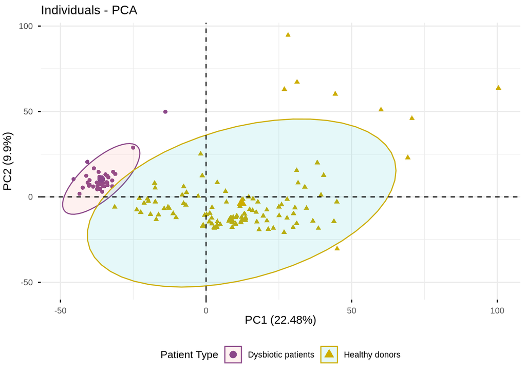

```r
#Individual scores --> a list of matrices containing all the results for the active individuals (coordinates, square cosine, contributions)
comp_ind <- pca_skg$ind$coord

#Plotting the PCA results with fviz_pca_ind (part of the factoextra package), uses ggplot2 internally
pca_sgk_all_plot <- fviz_pca_ind(pca_skg,
             label="none",
             habillage = 1, #Categorical data that separates results, here 'patient_type'
             addEllipses = TRUE,
             ellipse.level = 0.95,
             legend.title = "Patient Type",
             axes = c(1, 2), # Display PC1 and PC2
             xlab = paste0("PC1 (", round(pca_skg$eig[1, 2], 2), "%)"), #PC1
             ylab = paste0("PC2 (", round(pca_skg$eig[2, 2], 2), "%)")) + #PC2
  scale_colour_manual(values = c("Healthy donors" = "gold3", "Dysbiotic patients" = "orchid4")) +
  theme(text = element_text(size = 10),
        axis.title.y = element_text(vjust = +2, size = 11),
        axis.title.x = element_text(vjust = +2, size = 11),
        legend.position = "bottom",
        legend.box = "vertical",  # Stack legends vertically
        legend.text = element_text(size = rel(0.8)))

pca_sgk_all_plot
```

```r
#ggsave("Figures_paper/SupFigS2.PCA_all_regions.jpeg", width = 6, height = 4, units = "in", dpi = 600)
```

PCA - SCFAs levels

SCFA levels + IR data:

```r
#SCFA + IR DATA
scfa_total <- rbind(scfa_hd, scfa_cdiff)
scfa_total <- scfa_total %>% remove_rownames %>% column_to_rownames(var='sample_id')

#SCFA BOXPLOTS
scfa_boxplots <- scfa_total %>% mutate(patient_type = rep(c("healthy_donors", "cdiff_patients"), times = c(115, 39)))

#Use the ir_filtered to ensure we are using the selected regions of SCFAs
ftir_total <- merge(ir_filtered, scfa_total, by = "row.names", all = FALSE) #Join by sample id, in this case is the row name
rownames(ftir_total) <- ftir_total$Row.names #Column "row.names" back to indeed row names
ftir_total <- ftir_total[, -1]  #Drop the Row.names column

ftir_total <- ftir_total %>% dplyr::select(-patient_type) %>% dplyr::select(acetate, propionate, butyrate, everything())  #Places the SCFAs at the begining
```

ACETATE (Supp. Fig. S4A and B)

PCA acetate (Supplementary Figure S4 A):

```r
#ACETATE
#Quartiles acetate
acetate_ftir <- ftir_total %>% #Select acetate
  mutate(acetate_quartiles = ntile(acetate, 10)) %>% #Divide 'acetate' into quartiles
  dplyr::select(acetate, acetate_quartiles, everything()) %>%
  mutate(acetate_levels = case_when(acetate_quartiles == "10" ~ "High acetate",
                                    acetate_quartiles == "1" ~ "Low acetate",
                                    TRUE ~ "Other")) %>% #Qualitative tags
  dplyr::select(acetate_levels, everything()) %>%
  dplyr::select(-acetate_quartiles, -acetate, -propionate, -butyrate) #Drop SCFAs and patient type, we only want the quartiles

#NOTE!: The quartiles are made with all the data, not by groups (C.diff vs. Healthy)

#PCA - ACETATE LEVELS
#The variable 'acetate_levels' (column = 1) is removed before the PCA analysis, is qualitative
pca_acetate <- PCA(acetate_ftir, ncp = 5, scale = TRUE, quali.sup = 1)
```

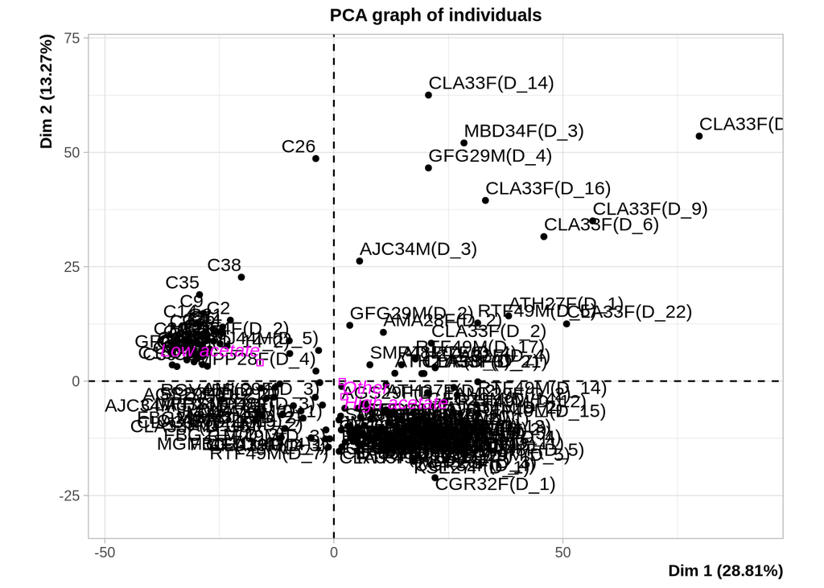

```r
#OUTPUTS PCA
summary(pca_acetate)  #Summary of PCA
```

```
##
## Call:
## PCA(X = acetate_ftir, scale.unit = TRUE, ncp = 5, quali.sup = 1)
##
##
## Eigenvalues
##                        Dim.1   Dim.2   Dim.3   Dim.4   Dim.5   Dim.6   Dim.7
## Variance             453.254 208.704 119.176  71.023  63.648  53.599  38.474
## % of var.             28.815  13.268   7.576   4.515   4.046   3.407   2.446
## Cumulative % of var.  28.815  42.082  49.659  54.174  58.220  61.628  64.074
##                        Dim.8   Dim.9  Dim.10  Dim.11  Dim.12  Dim.13  Dim.14
## Variance              35.252  27.300  24.164  20.988  20.582  19.193  17.786
## % of var.              2.241   1.736   1.536   1.334   1.308   1.220   1.131
## Cumulative % of var.  66.315  68.050  69.586  70.921  72.229  73.449  74.580
##                       Dim.15  Dim.16  Dim.17  Dim.18  Dim.19  Dim.20  Dim.21
## Variance              16.556  15.588  14.376  13.731  13.225  12.686  11.767
## % of var.              1.053   0.991   0.914   0.873   0.841   0.806   0.748
## Cumulative % of var.  75.632  76.623  77.537  78.410  79.251  80.057  80.805
##                       Dim.22  Dim.23  Dim.24  Dim.25  Dim.26  Dim.27  Dim.28
## Variance              11.180  10.907  10.018   9.542   8.990   8.871   8.584
## % of var.              0.711   0.693   0.637   0.607   0.572   0.564   0.546
## Cumulative % of var.  81.516  82.210  82.846  83.453  84.024  84.588  85.134
##                       Dim.29  Dim.30  Dim.31  Dim.32  Dim.33  Dim.34  Dim.35
## Variance               8.209   7.704   7.456   7.246   7.158   6.939   6.510
## % of var.              0.522   0.490   0.474   0.461   0.455   0.441   0.414
## Cumulative % of var.  85.656  86.146  86.620  87.080  87.536  87.977  88.391
##                       Dim.36  Dim.37  Dim.38  Dim.39  Dim.40  Dim.41  Dim.42
## Variance               6.340   6.065   5.799   5.668   5.601   5.247   5.102
## % of var.              0.403   0.386   0.369   0.360   0.356   0.334   0.324
## Cumulative % of var.  88.794  89.179  89.548  89.908  90.264  90.598  90.922
##                       Dim.43  Dim.44  Dim.45  Dim.46  Dim.47  Dim.48  Dim.49
## Variance               4.783   4.677   4.597   4.504   4.230   4.102   4.025
## % of var.              0.304   0.297   0.292   0.286   0.269   0.261   0.256
## Cumulative % of var.  91.226  91.524  91.816  92.102  92.371  92.632  92.888
##                       Dim.50  Dim.51  Dim.52  Dim.53  Dim.54  Dim.55  Dim.56
## Variance               3.858   3.787   3.657   3.581   3.477   3.390   3.346
## % of var.              0.245   0.241   0.233   0.228   0.221   0.215   0.213
## Cumulative % of var.  93.133  93.374  93.606  93.834  94.055  94.270  94.483
##                       Dim.57  Dim.58  Dim.59  Dim.60  Dim.61  Dim.62  Dim.63
## Variance               3.259   2.987   2.929   2.669   2.641   2.566   2.476
```

[output cut: 97 more lines]

```
## 3595           0.084 |
## 3594           0.105 |
## 3593           0.111 |
## 3592           0.069 |
## 3591           0.039 |
##
## Supplementary categories
##                    Dist     Dim.1    cos2  v.test     Dim.2    cos2  v.test
## High acetate  |  11.380 |   2.219   0.038   0.424 |  -3.406   0.090  -0.958 |
## Low acetate   |  18.186 | -16.130   0.787  -3.191 |   4.021   0.049   1.172 |
## Other         |   2.361 |   1.828   0.599   2.115 |  -0.108   0.002  -0.184 |
##                 Dim.3    cos2  v.test
## High acetate    5.984   0.276   2.227 |
## Low acetate     0.939   0.003   0.362 |
## Other          -0.852   0.130  -1.923 |
```

```r
#Eigenvalues --> a matrix containing all the eigenvalues, the percentage of variance and the cumulative percentage of variance
pca_acetate$eig
```

```
##            eigenvalue percentage of variance cumulative percentage of variance
## comp 1   4.532537e+02           2.881460e+01                          28.81460
## comp 2   2.087037e+02           1.326788e+01                          42.08248
## comp 3   1.191758e+02           7.576339e+00                          49.65882
## comp 4   7.102294e+01           4.515127e+00                          54.17395
## comp 5   6.364752e+01           4.046250e+00                          58.22020
## comp 6   5.359896e+01           3.407435e+00                          61.62763
## comp 7   3.847430e+01           2.445919e+00                          64.07355
## comp 8   3.525152e+01           2.241037e+00                          66.31459
## comp 9   2.730042e+01           1.735564e+00                          68.05015
## comp 10  2.416396e+01           1.536170e+00                          69.58632
## comp 11  2.098800e+01           1.334265e+00                          70.92059
## comp 12  2.058163e+01           1.308432e+00                          72.22902
## comp 13  1.919263e+01           1.220129e+00                          73.44915
## comp 14  1.778614e+01           1.130714e+00                          74.57986
## comp 15  1.655585e+01           1.052502e+00                          75.63236
## comp 16  1.558783e+01           9.909617e-01                          76.62333
## comp 17  1.437558e+01           9.138956e-01                          77.53722
## comp 18  1.373073e+01           8.729008e-01                          78.41012
## comp 19  1.322495e+01           8.407468e-01                          79.25087
## comp 20  1.268611e+01           8.064913e-01                          80.05736
## comp 21  1.176722e+01           7.480751e-01                          80.80544
## comp 22  1.117957e+01           7.107162e-01                          81.51615
## comp 23  1.090676e+01           6.933733e-01                          82.20953
## comp 24  1.001777e+01           6.368575e-01                          82.84638
## comp 25  9.541855e+00           6.066023e-01                          83.45299
## comp 26  8.989917e+00           5.715141e-01                          84.02450
## comp 27  8.870928e+00           5.639497e-01                          84.58845
## comp 28  8.583565e+00           5.456812e-01                          85.13413
## comp 29  8.209152e+00           5.218787e-01                          85.65601
## comp 30  7.703783e+00           4.897510e-01                          86.14576
## comp 31  7.456072e+00           4.740033e-01                          86.61976
## comp 32  7.246386e+00           4.606730e-01                          87.08044
## comp 33  7.158486e+00           4.550849e-01                          87.53552
## comp 34  6.939411e+00           4.411577e-01                          87.97668
## comp 35  6.509787e+00           4.138453e-01                          88.39052
## comp 36  6.339771e+00           4.030370e-01                          88.79356
## comp 37  6.065455e+00           3.855979e-01                          89.17916
## comp 38  5.798886e+00           3.686513e-01                          89.54781
## comp 39  5.667920e+00           3.603255e-01                          89.90814
```

[output cut: 99 more lines]

```
## comp 139 1.441362e-01           9.163141e-03                          99.92103
## comp 140 1.403678e-01           8.923576e-03                          99.92995
## comp 141 1.370297e-01           8.711359e-03                          99.93867
## comp 142 1.251121e-01           7.953725e-03                          99.94662
## comp 143 1.211299e-01           7.700567e-03                          99.95432
## comp 144 1.168161e-01           7.426323e-03                          99.96175
## comp 145 1.045733e-01           6.648017e-03                          99.96839
## comp 146 9.952015e-02           6.326774e-03                          99.97472
## comp 147 9.367043e-02           5.954890e-03                          99.98068
## comp 148 8.341799e-02           5.303114e-03                          99.98598
## comp 149 8.062570e-02           5.125600e-03                          99.99110
## comp 150 6.530870e-02           4.151856e-03                          99.99526
## comp 151 5.752795e-02           3.657212e-03                          99.99891
## comp 152 1.275995e-02           8.111857e-04                          99.99972
## comp 153 4.331812e-03           2.753854e-04                         100.00000
```

```r
#Coordinates (loadings) --> a list of matrices containing all the results for the active variables (coordinates, correlation between variables and axes, square cosine, contributions)
pca_acetate$var$coord
```

```
##             Dim.1         Dim.2         Dim.3         Dim.4         Dim.5
## 3600 -0.483854029  0.2132187555  4.081423e-01 -0.3281422169 -0.0010832395
## 3599 -0.177433303  0.1048127079  3.860959e-01 -0.3528123482 -0.0077648610
## 3598  0.297748012 -0.1044169791  1.520580e-01 -0.1729437663  0.0681347164
## 3597  0.444377220 -0.1896569924 -1.218936e-01  0.0918066603  0.1407992083
## 3596  0.356475640 -0.1565674669 -2.370315e-01  0.2249101736  0.1731171313
## 3595  0.305710605 -0.1106922610 -2.900403e-01  0.2751386422  0.1641773572
## 3594  0.375945633 -0.0808533197 -3.244439e-01  0.2680832615  0.1093192668
## 3593  0.607892678 -0.0846111841 -3.335887e-01  0.1816209121 -0.0127975453
## 3592  0.806927212 -0.1149992561 -2.620689e-01  0.0276114074 -0.1429497390
## 3591  0.840351566 -0.1326771353 -1.966801e-01 -0.0618234751 -0.1974682679
## 3590  0.830014522 -0.1454542190 -1.669974e-01 -0.0979327022 -0.2146547167
## 3589  0.790236217 -0.1531462607 -1.535761e-01 -0.1171264543 -0.2236035266
## 3588  0.615458381 -0.1459202313 -1.360648e-01 -0.1331084899 -0.2259441911
## 3587 -0.396452226  0.0071137759  5.462346e-02 -0.0955310800 -0.0501296527
```

[output cut: 1559 more lines]

```
## Ignoring unknown labels:
## • fill : "Acetate levels"
## • linetype : "Acetate levels"
```

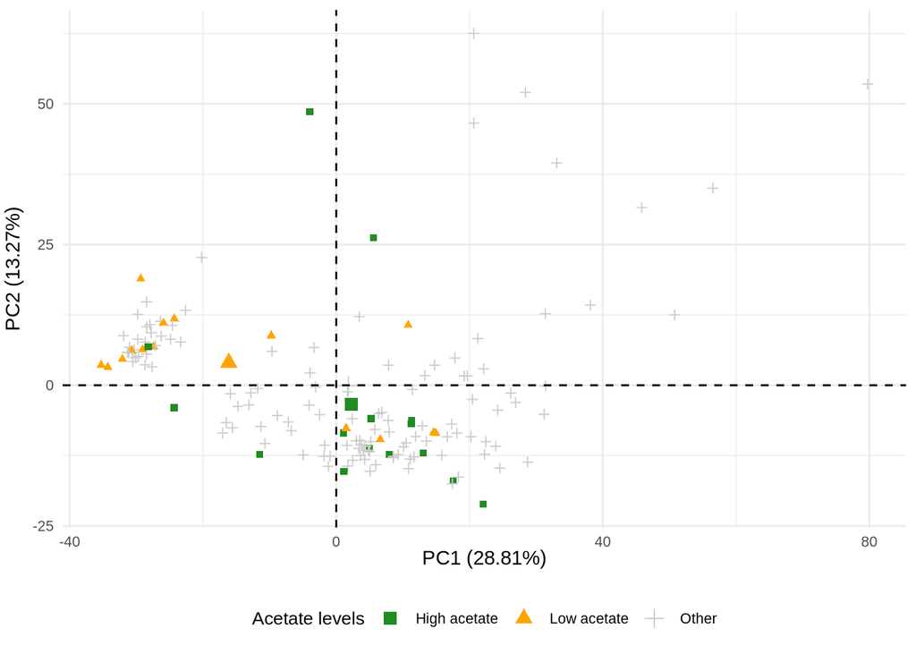

```r
#Individual scores --> a list of matrices containing all the results for the active individuals (coordinates, square cosine, contributions)
comp_ind <- pca_acetate$ind$coord

#Plotting the PCA results with fviz_pca_ind (part of the factoextra package), uses ggplot2 internally
pca_sgk_acetate <- fviz_pca_ind(pca_acetate,
             label="none",
             habillage = 1, #Categorical data that separates results, here 'acetate levels'
             addEllipses = FALSE,
             ellipse.level = 0.95,
             legend.title = "Acetate levels",
             axes = c(1, 2), # Display PC1 and PC2
             xlab = paste0("PC1 (", round(pca_acetate$eig[1, 2], 2), "%)"), #PC1
             ylab = paste0("PC2 (", round(pca_acetate$eig[2, 2], 2), "%)")) + #PC2
  scale_colour_manual(values = c("Other" = "gray80", "Low acetate" = "orange", "High acetate" = "forestgreen")) +
  scale_shape_manual(values = c("Other" = 3, "Low acetate" = 17, "High acetate" = 15)) +
  labs(title = NULL) +
  theme_minimal() +
  theme(text = element_text(size = 10),
        axis.title.y = element_text(vjust = +2, size = 11),
        axis.title.x = element_text(vjust = +2, size = 11),
        legend.position = "bottom",
        legend.text = element_text(size = rel(0.8)))

pca_sgk_acetate
```